# Sparveon - Copa de Cobre

## 1.2. Layer Stacking

Stack 10 bands into 515 tiles of 4000x4000 pixel

```python
from os import listdir
from os.path import isfile, join

# define the location of pre-processed raster images
tile_files = [f for f in listdir('./pre_processing/patch_images_4k/band_sentinel/band_2/') if isfile(join('./pre_processing/patch_images_4k/band_sentinel/band_2/', f))]

# loop over each tiles in the directory
for i, path in enumerate(tile_files):
    tile_num = path.split("_")[-1].split(".")[-2]
    # load the images
    with rasterio.open(f"pre_processing/patch_images_4k/band_sentinel/band_2/tile_{tile_num}.tif"):
        band2  = rasterio.open(f"pre_processing/patch_images_4k/band_sentinel/band_2/tile_{tile_num}.tif")
        band3  = rasterio.open(f"pre_processing/patch_images_4k/band_sentinel/band_3/tile_{tile_num}.tif")
        band4  = rasterio.open(f"pre_processing/patch_images_4k/band_sentinel/band_4/tile_{tile_num}.tif")
        band5  = rasterio.open(f"pre_processing/patch_images_4k/band_sentinel/band_5/tile_{tile_num}.tif")
        band6  = rasterio.open(f"pre_processing/patch_images_4k/band_sentinel/band_6/tile_{tile_num}.tif")
        band7  = rasterio.open(f"pre_processing/patch_images_4k/band_sentinel/band_7/tile_{tile_num}.tif")
        band8  = rasterio.open(f"pre_processing/patch_images_4k/band_sentinel/band_8/tile_{tile_num}.tif")
        band8a = rasterio.open(f"pre_processing/patch_images_4k/band_sentinel/band_8a/tile_{tile_num}.tif")
        band11 = rasterio.open(f"pre_processing/patch_images_4k/band_sentinel/band_11/tile_{tile_num}.tif")
        band12 = rasterio.open(f"pre_processing/patch_images_4k/band_sentinel/band_12/tile_{tile_num}.tif")

        # we stack each 10 bands of each tiles into 1  tif files, but we write
        # 'count' on new profile as 12 for easiness of use after pre-processing
        band2_geo = band2.profile
        band2_geo.update({'count': 12})

        # save the tiles
        savePath = f"pre_processing/patch_images_4k/band_stack_4k_12band/"
        if not os.path.exists(savePath):
                            os.makedirs(savePath)

        with rasterio.open(f'{savePath}/new_tile_{tile_num}.tif', 'w', **band2_geo) as dest:
          dest.write(band2.read(1),2)
          dest.write(band3.read(1),3)
          dest.write(band4.read(1),4)
          dest.write(band5.read(1),5)
          dest.write(band6.read(1),6)
          dest.write(band7.read(1),7)
          dest.write(band8.read(1),8)
          dest.write(band8a.read(1),9)
          dest.write(band11.read(1),11)
          dest.write(band12.read(1),12)
          print(f"new_tile_{tile_num}.tif Saved!")
```

## 1.3. Read Raster

```python
# read raster file using rasterio
tile_num = 400      # you could change this number from 0-514 (number of tiles)
raster = rasterio.open(f'pre_processing/patch_images_4k/band_stack_4k_12band/new_tile_{tile_num}.tif')
raster.meta
```

```
{'count': 12,
 'crs': CRS.from_epsg(4326),
 'driver': 'GTiff',
 'dtype': 'uint16',
 'height': 4000,
 'nodata': None,
 'transform': Affine(8.9831117498416e-05, 0.0, -78.80425799035704,
       0.0, -8.98311174962561e-05, -6.832464963123945),
 'width': 4000}
```

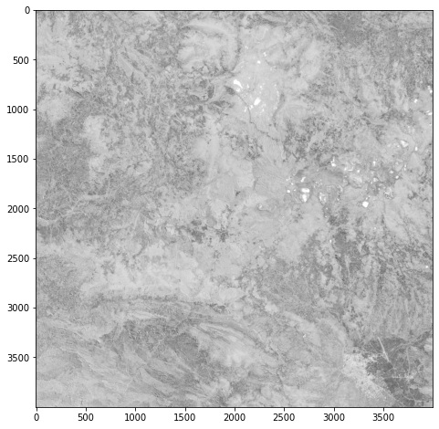

```python
# visualize raster file
band_sample = raster.read(8)   # you could change this band number's to 2,3,4,5,6,7,8,9(band 8a),11,12
fig, ax = plt.subplots(figsize=(8, 8))
plt.imshow(band_sample, cmap='gist_yarg')
plt.show()
```

## 1.4. Composite Band

### 1.4.1. Make a composite band

```python
# Make a composite band of RGB True Color (4,3,2)

from os import listdir
from os.path import isfile, join

# enumerate and call all the tile files in 'band_stack_4k_12band
tile_files = [f for f in listdir('./pre_processing/patch_images_4k/band_stack_4k_12band/') if isfile(join('./pre_processing/patch_images_4k/band_stack_4k_12band/', f))][:2]

for i, path in enumerate(tile_files):
    tile_num = path.split("_")[-1].split(".")[-2]

    # read tif files
    with rasterio.open(f"pre_processing/patch_images_4k/band_stack_4k_12band/new_tile_{tile_num}.tif"):
        img  = rasterio.open(f"pre_processing/patch_images_4k/band_stack_4k_12band/new_tile_{tile_num}.tif")
        # stack band 4,3, and 2, and transpose
        image = np.array([img.read(4), img.read(3), img.read(2)]).transpose(1,2,0)
        # find percentile image of 2-98
        p2, p98 = np.percentile(image, (2,98))
        # rescale image, divide by 10000
        image_resc = exposure.rescale_intensity(image, in_range=(p2, p98)) / 100000

        # re-transpose image
        out_image = image_resc.transpose(2,0,1)
        # re-write and update the meta and profile of image
        out_meta = img.meta
        out_meta.update({"driver": "GTiff", "height": out_image.shape[1], "width": out_image.shape[2], "transform": img.transform,
                         'count':4, 'dtype':'float64'})

        # save the composite band
        savePath = f"pre_processing/patch_images_4k/composite_4k/rgb_true_4k/"
        if not os.path.exists(savePath):
          os.makedirs(savePath)

        with rasterio.open(f'{savePath}/rgb_true_{tile_num}.tif', 'w', **out_meta) as dest:
          dest.write(out_image[2],2)
          dest.write(out_image[1],3)
          dest.write(out_image[0],4)
          print(f"rgb_true_{tile_num}.tif Saved!")
```

```python
# Make a composite band of False Infra-Red (8,4,3)

from os import listdir
from os.path import isfile, join

# enumerate and call all the tile files in 'band_stack_4k_12band
tile_files = [f for f in listdir('./pre_processing/patch_images_4k/band_stack_4k_12band/') if isfile(join('./pre_processing/patch_images_4k/band_stack_4k_12band/', f))][:2]

for i, path in enumerate(tile_files):
    tile_num = path.split("_")[-1].split(".")[-2]

    # read tif files
    with rasterio.open(f"pre_processing/patch_images_4k/band_stack_4k_12band/new_tile_{tile_num}.tif"):
        img  = rasterio.open(f"pre_processing/patch_images_4k/band_stack_4k_12band/new_tile_{tile_num}.tif")
        # stack band 8,4, and 3, and transpose
        image = np.array([img.read(8), img.read(4), img.read(3)]).transpose(1,2,0)
        # find percentile image of 2-98
        p2, p98 = np.percentile(image, (2,98))
        # rescale image, divide by 10000
        image_resc = exposure.rescale_intensity(image, in_range=(p2, p98)) / 100000

        # re-transpose image
        out_image = image_resc.transpose(2,0,1)
        # re-write and update the meta and profile of image
        out_meta = img.meta
        out_meta.update({"driver": "GTiff", "height": out_image.shape[1], "width": out_image.shape[2], "transform": img.transform,
                         'count':3, 'dtype':'float64'})

        # save the composite band
        savePath = f"pre_processing/patch_images_4k/composite_4k/false_ir_4k/"
        if not os.path.exists(savePath):
          os.makedirs(savePath)

        with rasterio.open(f'{savePath}/false_ir_{tile_num}.tif', 'w', **out_meta) as dest:
          dest.write(out_image)
          print(f"false_ir_4k{tile_num}.tif Saved!")
```

```python
# Make a composite band of Atmospheric Penetration (12,11,8a)

from os import listdir
from os.path import isfile, join

# enumerate and call all the tile files in 'band_stack_4k_12band
tile_files = [f for f in listdir('./pre_processing/patch_images_4k/band_stack_4k_12band/') if isfile(join('./pre_processing/patch_images_4k/band_stack_4k_12band/', f))][:2]

for i, path in enumerate(tile_files):
    tile_num = path.split("_")[-1].split(".")[-2]

    # read tif files
    with rasterio.open(f"pre_processing/patch_images_4k/band_stack_4k_12band/new_tile_{tile_num}.tif"):
        img  = rasterio.open(f"pre_processing/patch_images_4k/band_stack_4k_12band/new_tile_{tile_num}.tif")
        # stack band 12,11, and 8a, and transpose
        image = np.array([img.read(12), img.read(11), img.read(9)]).transpose(1,2,0)
        # find percentile image of 2-98
        p2, p98 = np.percentile(image, (2,98))
        # rescale image, divide by 10000
        image_resc = exposure.rescale_intensity(image, in_range=(p2, p98)) / 100000

        # re-transpose image
        out_image = image_resc.transpose(2,0,1)
        # re-write and update the meta and profile of image
        out_meta = img.meta
        out_meta.update({"driver": "GTiff", "height": out_image.shape[1], "width": out_image.shape[2], "transform": img.transform,
                         'count':3, 'dtype':'float64'})

        # save the composite band
        savePath = f"pre_processing/patch_images_4k/composite_4k/atm_4k/"
        if not os.path.exists(savePath):
          os.makedirs(savePath)

        with rasterio.open(f'{savePath}/atm_{tile_num}.tif', 'w', **out_meta) as dest:
          dest.write(out_image)
          print(f"atm_{tile_num}.tif Saved!")
```

```python
# Make a composite band of Geology (12,11,2)

from os import listdir
from os.path import isfile, join

# enumerate and call all the tile files in 'band_stack_4k_12band
tile_files = [f for f in listdir('./pre_processing/patch_images_4k/band_stack_4k_12band/') if isfile(join('./pre_processing/patch_images_4k/band_stack_4k_12band/', f))][:2]

for i, path in enumerate(tile_files):
    tile_num = path.split("_")[-1].split(".")[-2]

    # read tif files
    with rasterio.open(f"pre_processing/patch_images_4k/band_stack_4k_12band/new_tile_{tile_num}.tif"):
        img  = rasterio.open(f"pre_processing/patch_images_4k/band_stack_4k_12band/new_tile_{tile_num}.tif")
        # stack band 12,11, and 2, and transpose
        image = np.array([img.read(12), img.read(11), img.read(2)]).transpose(1,2,0)
        # find percentile image of 2-98
        p2, p98 = np.percentile(image, (2,98))
        # rescale image, divide by 10000
        image_resc = exposure.rescale_intensity(image, in_range=(p2, p98)) / 100000

        # re-transpose image
        out_image = image_resc.transpose(2,0,1)
        # re-write and update the meta and profile of image
        out_meta = img.meta
        out_meta.update({"driver": "GTiff", "height": out_image.shape[1], "width": out_image.shape[2], "transform": img.transform,
                         'count':3, 'dtype':'float64'})

        # save the composite band
        savePath = f"pre_processing/patch_images_4k/composite_4k/geology_4k/"
        if not os.path.exists(savePath):
          os.makedirs(savePath)

        with rasterio.open(f'{savePath}/geology_{tile_num}.tif', 'w', **out_meta) as dest:
          dest.write(out_image)
          print(f"geology_{tile_num}.tif Saved!")
```

```python
# Make a composite band of Agriculture (11,8,2)

from os import listdir
from os.path import isfile, join

# enumerate and call all the tile files in 'band_stack_4k_12band
tile_files = [f for f in listdir('./pre_processing/patch_images_4k/band_stack_4k_12band/') if isfile(join('./pre_processing/patch_images_4k/band_stack_4k_12band/', f))][:2]

for i, path in enumerate(tile_files):
    tile_num = path.split("_")[-1].split(".")[-2]

    # read tif files
    with rasterio.open(f"pre_processing/patch_images_4k/band_stack_4k_12band/new_tile_{tile_num}.tif"):
        img  = rasterio.open(f"pre_processing/patch_images_4k/band_stack_4k_12band/new_tile_{tile_num}.tif")
        # stack band 11, 8, and 2, and transpose
        image = np.array([img.read(11), img.read(8), img.read(2)]).transpose(1,2,0)
        # find percentile image of 2-98
        p2, p98 = np.percentile(image, (2,98))
        # rescale image, divide by 10000
        image_resc = exposure.rescale_intensity(image, in_range=(p2, p98)) / 100000

        # re-transpose image
        out_image = image_resc.transpose(2,0,1)
        # re-write and update the meta and profile of image
        out_meta = img.meta
        out_meta.update({"driver": "GTiff", "height": out_image.shape[1], "width": out_image.shape[2], "transform": img.transform,
                         'count':3, 'dtype':'float64'})

        # save the composite band
        savePath = f"pre_processing/patch_images_4k/composite_4k/agri_4k/"
        if not os.path.exists(savePath):
          os.makedirs(savePath)

        with rasterio.open(f'{savePath}/agri_{tile_num}.tif', 'w', **out_meta) as dest:
          dest.write(out_image)
          print(f"agri_{tile_num}.tif Saved!")
```

```python
# Make a composite band of SWIR (12,8,4)

from os import listdir
from os.path import isfile, join

# enumerate and call all the tile files in 'band_stack_4k_12band
tile_files = [f for f in listdir('./pre_processing/patch_images_4k/band_stack_4k_12band/') if isfile(join('./pre_processing/patch_images_4k/band_stack_4k_12band/', f))][:2]

for i, path in enumerate(tile_files):
    tile_num = path.split("_")[-1].split(".")[-2]

    # read tif files
    with rasterio.open(f"pre_processing/patch_images_4k/band_stack_4k_12band/new_tile_{tile_num}.tif"):
        img  = rasterio.open(f"pre_processing/patch_images_4k/band_stack_4k_12band/new_tile_{tile_num}.tif")
        # stack band 12, 8, and 4, and transpose
        image = np.array([img.read(12), img.read(8), img.read(4)]).transpose(1,2,0)
        # find percentile image of 2-98
        p2, p98 = np.percentile(image, (2,98))
        # rescale image, divide by 10000
        image_resc = exposure.rescale_intensity(image, in_range=(p2, p98)) / 100000

        # re-transpose image
        out_image = image_resc.transpose(2,0,1)
        # re-write and update the meta and profile of image
        out_meta = img.meta
        out_meta.update({"driver": "GTiff", "height": out_image.shape[1], "width": out_image.shape[2], "transform": img.transform,
                         'count':3, 'dtype':'float64'})

        # save the composite band
        savePath = f"pre_processing/patch_images_4k/composite_4k/swir_4k/"
        if not os.path.exists(savePath):
          os.makedirs(savePath)

        with rasterio.open(f'{savePath}/swir_{tile_num}.tif', 'w', **out_meta) as dest:
          dest.write(out_image)
          print(f"swir_{tile_num}.tif Saved!")
```

### 1.4.2. Read a composite band

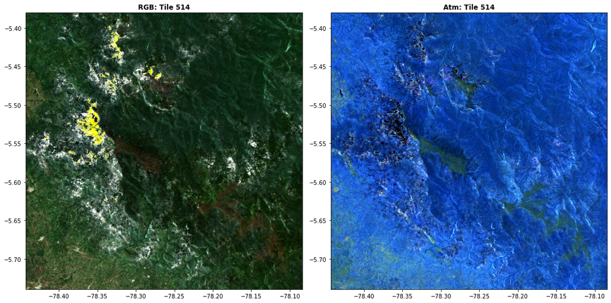

```python
tile_num = 514     # you could change this from 0-514
# select 2 composite band
rgb  = rasterio.open(f'pre_processing/patch_images_4k/composite_4k/rgb_true_4k/rgb_true_{tile_num}.tif')
#fir  = rasterio.open(f'pre_processing/patch_images_4k/composite_4k/false_ir_4k/false_ir_{tile_num}.tif')
atm  = rasterio.open(f'pre_processing/patch_images_4k/composite_4k/atm_4k/atm_{tile_num}.tif')
#geo  = rasterio.open(f'pre_processing/patch_images_4k/composite_4k/geology_4k/geology_{tile_num}.tif')
#agri = rasterio.open(f'pre_processing/patch_images_4k/composite_4k/agri_4k/agri_{tile_num}.tif')
#swir = rasterio.open(f'pre_processing/patch_images_4k/composite_4k/swir_4k/swir_{tile_num}.tif')

# Stack 3 band
rgb1  = np.dstack((adjust_band(rgb.read(4)), adjust_band(rgb.read(3)), adjust_band(rgb.read(2)))).transpose(2,0,1) # normalization w/ adjust_band
#fir1  = np.dstack((adjust_band(fir.read(3)), adjust_band(fir.read(2)), adjust_band(fir.read(1)))).transpose(2,0,1) # normalization w/ adjust_band
atm1  = np.dstack((adjust_band(atm.read(3)), adjust_band(atm.read(2)), adjust_band(atm.read(1)))).transpose(2,0,1) # normalization w/ adjust_band
#geo1  = np.dstack((adjust_band(geo.read(3)), adjust_band(geo.read(2)), adjust_band(geo.read(1)))).transpose(2,0,1) # normalization w/ adjust_band
#agri1 = np.dstack((adjust_band(agri.read(3)), adjust_band(agri.read(2)), adjust_band(agri.read(1)))).transpose(2,0,1) # normalization w/ adjust_band
#swir1 = np.dstack((adjust_band(swir.read(3)), adjust_band(swir.read(2)), adjust_band(swir.read(1)))).transpose(2,0,1) # normalization w/ adjust_band

# Color composite
fig, ax = plt.subplots(1,2,figsize=(15,15))
show(rgb1, transform=rgb.transform, ax=ax[0], title=f'RGB: Tile {tile_num}')
#show(fir1, transform=fir.transform, ax=ax[1], title=f'False IR: Tile {tile_num}')
show(atm1, transform=atm.transform, ax=ax[1], title=f'Atm: Tile {tile_num}')
#show(geo1,  transform=geo.transform,  ax=ax[1], title=f'Geo: Tile {tile_num}')
#show(agri1, transform=agri.transform, ax=ax[1], title=f'Agri: Tile {tile_num}')
#show(swir1, transform=swir.transform, ax=ax[1], title=f'SWIR: Tile {tile_num}')
plt.tight_layout()
```

# 2. Processing

If you face an error during running the codebase in our Jupyter Notebook, especially in processing step, for example:

- Error during running ‘Cloud Masking with s2cloudless’, it is likely that the dimensions of 2 images are not matched. Check the shape/dimensions of images, then try to change the parameter of ‘tile_num’ that has the same dimensions of 4000x4000 pixel and mask them first. And then match up the images with different dimensions (eg. 4000x3999 px, 4001x4000 px, 4001x3999 px) later.
- Error during running ‘Band Ratio’ and ‘Threshold’, it is likely that the images did not have the mask value. Try to adjust the enumeration range of the number in ‘tile_num’ parameter manually (for loop: `for i, tile_num in enumerate(range(0,515)):`, adjust to `for i, tile_num in enumerate(range(1,515)):`, etc.), because images with no mask could not be processed.
- Feel free to contact us if you need a hand for running this notebook

## 2.1. Cloud Masking

We use `S2PixelCloudDetector` of `s2cloudless` from Sentinel-Hub's https://github.com/sentinel-hub/sentinel2-cloud-detector for detecting cloud in our raster file.

Here are the documentation from `s2cloudless`:

We can specify the following arguments in the initialization of a `S2PixelCloudDetector`:

- `threshold` - cloud probability threshold value. All pixels with cloud probability above threshold value are masked as cloudy pixels. Default is `0.4`.
- `all_bands` - Flag specifying that input images will consists of all 13 Sentinel-2 bands. It has to be set to `True` if we would download all bands. If you define a layer that would return only 10 bands, then this parameter should be set to `False`.
- `average_over` - Size of the disk in pixels for performing convolution (averaging probability over pixels). For this resolution `4` is appropriate.
- `dilation_size` - Size of the disk in pixels for performing dilation. For this resolution `2` is appropriate. Run the classification

There are two possibilities:

- `get_cloud_probability_maps` will return cloud probability map
- `get_cloud_masks` will return binary cloud masks

Notes:

As our implementation of `s2cloudless` on the dataset, we could not make the automation loop for cloud detection in 1 runtime process. This is due to the limitation of the resources, as Google Colab sometimes will crash if we process more than 2 images per 1 runtime process. So, for the good of our work, we process the cloud detection just for 2 images per 1 runtime process.

### 2.1.1. Cloud masking with 's2cloudless'

```python
# change the number of 'tile_num_0' and 'tile_num_1' from 0 to 514,
# as we loop over the cloud detection on raster dataset manually.
tile_num_0 = 0
tile_num_1 = 1

# open 2 raster files
raster_0 = rasterio.open(f'pre_processing/patch_images_4k/band_stack_4k_12band/new_tile_{tile_num_0}.tif')
raster_1 = rasterio.open(f'pre_processing/patch_images_4k/band_stack_4k_12band/new_tile_{tile_num_1}.tif')
```

```python
# read 10 bands of each raster. 's2cloudless' require band no. 1, 2, 4, 5, 8,
# 8A, 9, 10, 11, 12, but we provide it with what band number we've got, and stack
# them into an image.
image_0 = np.array([raster_0.read(2), raster_0.read(2), raster_0.read(4),
                    raster_0.read(5), raster_0.read(8), raster_0.read(9),
                    raster_0.read(9), raster_0.read(11), raster_0.read(11), raster_0.read(12)]).transpose(1,2,0)

# find percentile of 2%-98% for each image, divide with 10000 to get the reflectance
p2, p98 = np.percentile(image_0, (2,98))
image_resc_0 = exposure.rescale_intensity(image_0, in_range=(p2, p98)) / 100000
```

```python
# same as previous process, apply it to the second raster
image_1 = np.array([raster_1.read(2), raster_1.read(2), raster_1.read(4),
                    raster_1.read(5), raster_1.read(8), raster_1.read(9),
                    raster_1.read(9), raster_1.read(11), raster_1.read(11), raster_1.read(12)]).transpose(1,2,0)
p2, p98 = np.percentile(image_1, (2,98))
image_resc_1 = exposure.rescale_intensity(image_1, in_range=(p2, p98)) / 100000
```

```python
# stack 2 images into 4-Dimensions shape of image array
image_new = np.stack((image_resc_0, image_resc_1))
```

```python
# run 'S2PixelCloudDetector' to detect cloud with threshold=0.7, average_over=0, dilation_size=0
cloud_masks_resc = S2PixelCloudDetector(threshold=0.7, average_over=0, dilation_size=0).get_cloud_masks(image_new)
```

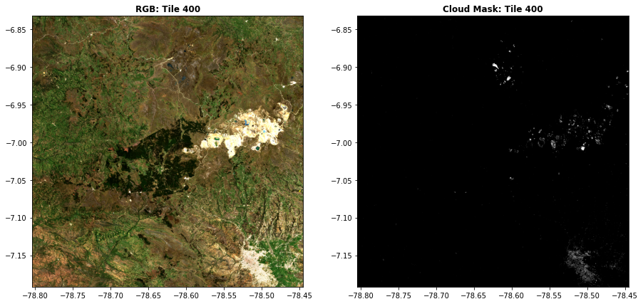

```python
# visualize the mask, compare with RGB True Colour for 'tile_num_1'
tile_num_1 = 400
fig, ax = plt.subplots(1,2,figsize=(15,15))

rgb  = rasterio.open(f'pre_processing/patch_images_4k/composite_4k/rgb_true_4k/rgb_true_{tile_num_1}.tif')
rgb1  = np.dstack((adjust_band(rgb.read(4)), adjust_band(rgb.read(3)), adjust_band(rgb.read(2)))).transpose(2,0,1) # normalization w/ adjust_band
mask  = rasterio.open(f'processing/mask_uint_tif/mask_uint_{tile_num_1}.tif')

show(rgb1, transform=rgb.transform, ax=ax[0], title=f'RGB: Tile {tile_num_1}')
show(mask, transform=mask.transform, ax=ax[1], cmap='gray', title=f'Cloud Mask: Tile {tile_num_1}')
```

```python
# call the cloud masks into object, and convert dtype to uint8
cloud_masks_0 = cloud_masks_resc[0]
cloud_masks_1 = cloud_masks_resc[1]

cloud_masks_0_uint = np.array(cloud_masks_0, dtype=np.uint8)
cloud_masks_1_uint = np.array(cloud_masks_1, dtype=np.uint8)

# save each of cloud masks into a tif file with 1 band, and repeat from
# the first step for 515 tiles
mask_uint_0 = rasterio.open(f'processing/mask_uint_tif/mask_uint_{tile_num_0}.tif', 'w', driver='GTiff',
                            height = cloud_masks_0_uint.shape[0], width = cloud_masks_0_uint.shape[1],
                            count=1, dtype=str(cloud_masks_0_uint.dtype), crs=raster_0.crs, transform=raster_0.transform)
mask_uint_0.write(cloud_masks_0_uint, 1)
mask_uint_0.close()

mask_uint_1 = rasterio.open(f'processing/mask_uint_tif/mask_uint_{tile_num_1}.tif', 'w', driver='GTiff',
                            height = cloud_masks_1_uint.shape[0], width = cloud_masks_1_uint.shape[1],
                            count=1, dtype=str(cloud_masks_1_uint.dtype), crs=raster_1.crs, transform=raster_1.transform)
mask_uint_1.write(cloud_masks_1_uint, 1)
mask_uint_1.close()
```

### 2.1.2. Generate polygons of masks from tif file, into GeoJSON file

```python
from os import listdir
from os.path import isfile, join

# create a for loop, enumerate tif file of masks in the directory
tile_files = [f for f in listdir('processing/mask_uint_tif/') if isfile(join('processing/mask_uint_tif', f))]
for i, path in enumerate(tile_files):
    tile_num = path.split("_")[-1].split(".")[-2]

#for i, tile_num in enumerate(range(0,515)):

    mask = None
    with rasterio.Env():
      # load the image
      with rasterio.open(f'processing/mask_uint_tif/mask_uint_{tile_num}.tif') as src:
        # read the first band
        image = src.read(1)
        src = rasterio.open(f'processing/mask_uint_tif/mask_uint_{tile_num}.tif')
        # variable that will contain the generated polygons
        results = ({'properties': {'raster_val': v}, 'geometry': s}
        for i, (s, v) in enumerate(shapes(image, mask=mask, transform=src.transform)))
        # create a list from the results that looks like a geojson features file
        geoms = list(results)
        # create a geodataframe from the feature files
        gdf  = gpd.GeoDataFrame.from_features(geoms)
        # we will use just the raster values that have the value 1
        gdf  = gdf[gdf["raster_val"] == 1]

        # create save path
        savePath = f"processing/gdf_mask_geojson/"
        if not os.path.exists(savePath):
          os.makedirs(savePath)

        # save GeoDataFrame of masks into GeoJSON file
        gdf.to_file(f"{savePath}/gdf_mask_{tile_num}.geojson", driver="GeoJSON")
        print(f"gdf_mask_{tile_num}.geojson Saved!")
```

### 2.1.3. Overlay tif file from Raw Data, with polygons of masks inside GeoJSON file

```python
# create a for loop, enumerate GeoJSON file of masks in the directory
tile_files = [f for f in listdir('processing/gdf_mask_geojson/') if isfile(join('processing/gdf_mask_geojson', f))]
for i, path in enumerate(tile_files):
    tile_num = path.split("_")[-1].split(".")[-2]

#for i, tile_num in enumerate(range(0,515)):

    # read 'geometry' feature of mask with fiona
    with fiona.open(f'processing/gdf_mask_geojson/gdf_mask_{tile_num}.geojson', "r") as shapefile:
      # Generate a list with the geometry of the shapes
      shapes = [feature["geometry"] for feature in shapefile]

    # read tif file from Raw Data with rasterio, and write a new overlayed tif file
    with rasterio.open(f'pre_processing/patch_images_4k/band_stack_4k_12band/new_tile_{tile_num}.tif') as src:
      # overlay raw raster with masks, set 'invert' to True so pixels inside shape will be masked.
      out_image, out_transform = rasterio.mask.mask(src, shapes, invert=True)
      out_meta = src.meta.copy()
      out_meta.update({"driver": "GTiff",
                       "height": out_image.shape[1],
                       "width": out_image.shape[2],
                       "transform": out_transform})

      # create save path
      savePath = f"processing/tile_masked_tif/"
      if not os.path.exists(savePath):
          os.makedirs(savePath)

      # write new masked tif file
      with rasterio.open(f"{savePath}/tile_mask_{tile_num}.tif", "w", **out_meta) as dest:
          dest.write(out_image)
          print(f"tile_mask_{tile_num}.tif Saved!")
```

## 2.2. Band Ratio

### 2.2.1. Process all masked raster with 7 band ratio

##### 2.2.1.1. Advance Argillic band ratio (Band 8a/Band12)

```python
# Advance Argillic band ratio (Band 8a/Band12)
from os import listdir
from os.path import isfile, join

# set 0 value to be ignored when math processing
np.seterr(divide='ignore', invalid='ignore')

# create a for loop, enumerate masked tif file in the directory
for i, tile_num in enumerate(range(0,515)):

    # read raster file
    with rasterio.open(f"processing/tile_masked_tif/tile_mask_{tile_num}.tif"):
        raster = rasterio.open(f'processing/tile_masked_tif/tile_mask_{tile_num}.tif')
        # process Band 8a/Band 12 to get Advance Argillic band ratio
        band8a = raster.read(9)
        band12 = raster.read(12)
        adv_argillic_ratio = band8a/band12

        # create save path
        savePath = f"processing/band_ratio/adv_argillic_tile/"
        if not os.path.exists(savePath):
                            os.makedirs(savePath)

        # write new tif file of 1 Advance Argillic band
        adv_argillic = rasterio.open(f'{savePath}/adv_argillic_tile_{tile_num}.tif', 'w', driver='GTiff',
                                     height = adv_argillic_ratio.shape[0], width = adv_argillic_ratio.shape[1],
                                     count=1, dtype=str(adv_argillic_ratio.dtype),
                                     crs=raster.crs, transform=raster.transform)
        adv_argillic.write(adv_argillic_ratio, 1)
        adv_argillic.close()
        print(f"adv_argillic_tile_{tile_num}.tif Saved!")
```

##### 2.2.1.2. All Iron Oxides band ratio (Band 4/Band 2)

```python
# All Iron Oxides band ratio (Band 4/Band 2)

from os import listdir
from os.path import isfile, join

# set 0 value to be ignored when math processing
np.seterr(divide='ignore', invalid='ignore')

# create a for loop, enumerate masked tif file in the directory
for i, tile_num in enumerate(range(0,515)):

    # read raster file
    with rasterio.open(f"processing/tile_masked_tif/tile_mask_{tile_num}.tif"):
        raster = rasterio.open(f'processing/tile_masked_tif/tile_mask_{tile_num}.tif')
        # process Band 4/Band 2 to get All Iron Oxides band ratio
        band4 = raster.read(4)
        band2 = raster.read(2)
        all_iron_oxides_ratio = band4/band2

        # create save path
        savePath = f"processing/band_ratio/all_iron_oxides_tile/"
        if not os.path.exists(savePath):
                            os.makedirs(savePath)

        # write new tif file of 1 Argillic band
        all_iron_oxides = rasterio.open(f'{savePath}/all_iron_oxides_tile_{tile_num}.tif', 'w', driver='GTiff',
                                 height = all_iron_oxides_ratio.shape[0], width = all_iron_oxides_ratio.shape[1],
                                 count=1, dtype=str(all_iron_oxides_ratio.dtype),
                                 crs=raster.crs, transform=raster.transform)
        all_iron_oxides.write(all_iron_oxides_ratio, 1)
        all_iron_oxides.close()
        print(f"all_iron_oxides_tile_{tile_num}.tif Saved!")
```

##### 2.2.1.3. Argillic band ratio (Band 11/Band 12)

```python
# Argillic band ratio (Band 11/Band 12)

from os import listdir
from os.path import isfile, join

# set 0 value to be ignored when math processing
np.seterr(divide='ignore', invalid='ignore')

# create a for loop, enumerate masked tif file in the directory
for i, tile_num in enumerate(range(0,515)):

    # read raster file
    with rasterio.open(f"processing/tile_masked_tif/tile_mask_{tile_num}.tif"):
        raster = rasterio.open(f'processing/tile_masked_tif/tile_mask_{tile_num}.tif')
        # process Band 11/Band 12 to get Argillic band ratio
        band11 = raster.read(11)
        band12 = raster.read(12)
        argillic_ratio = band11/band12

        # create save path
        savePath = f"processing/band_ratio/argillic_tile/"
        if not os.path.exists(savePath):
                            os.makedirs(savePath)

        # write new tif file of 1 Argillic band
        argillic = rasterio.open(f'{savePath}/argillic_tile_{tile_num}.tif', 'w', driver='GTiff',
                                 height = argillic_ratio.shape[0], width = argillic_ratio.shape[1],
                                 count=1, dtype=str(argillic_ratio.dtype),
                                 crs=raster.crs, transform=raster.transform)
        argillic.write(argillic_ratio, 1)
        argillic.close()
        print(f"argillic_tile_{tile_num}.tif Saved!")
```

##### 2.2.1.4. Ferrous iron oxides band ratio (Band 4/Band 11)

```python
# Ferrous iron oxides band ratio (Band 4/Band 11)

from os import listdir
from os.path import isfile, join

# set 0 value to be ignored when math processing
np.seterr(divide='ignore', invalid='ignore')

# create a for loop, enumerate masked tif file in the directory
for i, tile_num in enumerate(range(0,515)):

    # read raster file
    with rasterio.open(f"processing/tile_masked_tif/tile_mask_{tile_num}.tif"):
        raster = rasterio.open(f'processing/tile_masked_tif/tile_mask_{tile_num}.tif')
        # process Band 4/Band 11 to get Ferrous Iron Oxides band ratio
        band4 = raster.read(4)
        band11 = raster.read(11)
        ferrous_iron_oxides_ratio = band4/band11

        # create save path
        savePath = f"processing/band_ratio/ferrous_iron_oxides_tile/"
        if not os.path.exists(savePath):
                            os.makedirs(savePath)

        # write new tif file of 1 Argillic band
        ferrous_iron_oxides = rasterio.open(f'{savePath}/ferrous_iron_oxides_tile_{tile_num}.tif', 'w', driver='GTiff',
                                 height = ferrous_iron_oxides_ratio.shape[0], width = ferrous_iron_oxides_ratio.shape[1],
                                 count=1, dtype=str(ferrous_iron_oxides_ratio.dtype),
                                 crs=raster.crs, transform=raster.transform)
        ferrous_iron_oxides.write(ferrous_iron_oxides_ratio, 1)
        ferrous_iron_oxides.close()
        print(f"ferrous_iron_oxides_tile_{tile_num}.tif Saved!")
```

##### 2.2.1.5. Oxide Zone band ratio (Band 11/Band 8)

```python
# Oxide Zone band ratio (Band 11/Band 8)
from os import listdir
from os.path import isfile, join

# set 0 value to be ignored when math processing
np.seterr(divide='ignore', invalid='ignore')

# create a for loop, enumerate masked tif file in the directory
for i, tile_num in enumerate(range(0,515)):

    # read raster file
    with rasterio.open(f"processing/tile_masked_tif/tile_mask_{tile_num}.tif"):
        raster = rasterio.open(f'processing/tile_masked_tif/tile_mask_{tile_num}.tif')
        # process Band 11/Band 8 to get Oxide Zone band ratio
        band11 = raster.read(11)
        band8  = raster.read(8)
        oxide_ratio = band11/band8

        # create save path
        savePath = f"processing/band_ratio/oxide_tile/"
        if not os.path.exists(savePath):
                            os.makedirs(savePath)

        # write new tif file of 1 Oxide Zone band
        oxide = rasterio.open(f'{savePath}/oxide_tile_{tile_num}.tif', 'w', driver='GTiff',
                                height = oxide_ratio.shape[0], width = oxide_ratio.shape[1],
                                count=1, dtype=str(oxide_ratio.dtype),
                                crs=raster.crs, transform=raster.transform)
        oxide.write(oxide_ratio, 1)
        oxide.close()
        print(f"oxide_tile_{tile_num}.tif Saved!")
```

##### 2.2.1.6. Propylitic A band ratio (Band 11/Band 5)

```python
# Propylitic A band ratio (Band 11/Band 5)
from os import listdir
from os.path import isfile, join

# set 0 value to be ignored when math processing
np.seterr(divide='ignore', invalid='ignore')

# create a for loop, enumerate masked tif file in the directory
for i, tile_num in enumerate(range(0,515)):

    # read raster file
    with rasterio.open(f"processing/tile_masked_tif/tile_mask_{tile_num}.tif"):
        raster = rasterio.open(f'processing/tile_masked_tif/tile_mask_{tile_num}.tif')
        # process Band 11/Band 5 to get Propylitic(A) band ratio
        band11 = raster.read(11)
        band5  = raster.read(5)
        propylitic_a_ratio = band11/band5

        # create save path
        savePath = f"processing/band_ratio/propylitic_a_tile/"
        if not os.path.exists(savePath):
                            os.makedirs(savePath)

        # write new tif file of 1 Propylitic(A) band
        propylitic_a = rasterio.open(f'{savePath}/propylitic_a_tile_{tile_num}.tif', 'w', driver='GTiff',
                                     height = propylitic_a_ratio.shape[0], width = propylitic_a_ratio.shape[1],
                                     count=1, dtype=str(propylitic_a_ratio.dtype),
                                     crs=raster.crs, transform=raster.transform)
        propylitic_a.write(propylitic_a_ratio, 1)
        propylitic_a.close()
        print(f"propylitic_a_tile_{tile_num}.tif Saved!")
```

##### 2.2.1.7. Propylitic B band ratio (Band 12/Band 5)

```python
# Propylitic B band ratio (Band 12/Band 5)
from os import listdir
from os.path import isfile, join

# set 0 value to be ignored when math processing
np.seterr(divide='ignore', invalid='ignore')

# create a for loop, enumerate masked tif file in the directory
for i, tile_num in enumerate(range(0,515)):

    # read raster file
    with rasterio.open(f"processing/tile_masked_tif/tile_mask_{tile_num}.tif"):
        raster = rasterio.open(f'processing/tile_masked_tif/tile_mask_{tile_num}.tif')
        # process Band 12/Band 5 to get Propylitic(B) band ratio
        band12 = raster.read(12)
        band5  = raster.read(5)
        propylitic_b_ratio = band12/band5

        # create save path
        savePath = f"processing/band_ratio/propylitic_b_tile/"
        if not os.path.exists(savePath):
                            os.makedirs(savePath)

        # write new tif file of 1 Propylitic(B) band
        propylitic_b = rasterio.open(f'{savePath}/propylitic_b_tile_{tile_num}.tif', 'w', driver='GTiff',
                                     height = propylitic_b_ratio.shape[0], width = propylitic_b_ratio.shape[1],
                                     count=1, dtype=str(propylitic_b_ratio.dtype),
                                     crs=raster.crs, transform=raster.transform)
        propylitic_b.write(propylitic_b_ratio, 1)
        propylitic_b.close()
        print(f"propylitic_b_tile_{tile_num}.tif Saved!")
```

## 2.3. Threshold

#### 2.3.1.1. Threshold in 'advance_argillic'

```python
### Threshold the value of 95%, 98%, and 98% for each processed band ratio raster in 'adv_argillic_tile'

from os import listdir
from os.path import isfile, join

# set 0 value to be ignored when math processing
np.seterr(divide='ignore', invalid='ignore')

# create a for loop, enumerate 515 masked tif files in the directory
for i, tile_num in enumerate(range(0,515)):

    # read raster file
    with rasterio.open(f"processing/band_ratio/adv_argillic_tile/adv_argillic_tile_{tile_num}.tif"):
        raster = rasterio.open(f'processing/band_ratio/adv_argillic_tile/adv_argillic_tile_{tile_num}.tif')
        # process raster into pandas DataFrame, and threshold the values above 95%, 98%, and 99%
        band_sample = raster.read(1)
        df_band = pd.DataFrame(band_sample)
        df_band_095_stack = np.array(df_band[df_band > df_band.stack().quantile(0.95)])
        df_band_098_stack = np.array(df_band[df_band > df_band.stack().quantile(0.98)])
        df_band_099_stack = np.array(df_band[df_band > df_band.stack().quantile(0.99)])

        # create save path for 'df_band_095_stack', 'df_band_098_stack', and 'df_band_099_stack'
        savePath_095 = f"processing/threshold/threshold_095/adv_argillic_thr_095"
        if not os.path.exists(savePath_095):
                            os.makedirs(savePath_095)
        savePath_098 = f"processing/threshold/threshold_098/adv_argillic_thr_098"
        if not os.path.exists(savePath_098):
                            os.makedirs(savePath_098)
        savePath_099 = f"processing/threshold/threshold_099/adv_argillic_thr_099/"
        if not os.path.exists(savePath_099):
                            os.makedirs(savePath_099)

        # write new tif file of 'df_band_095_stack'
        df_band_095 = rasterio.open(f'{savePath_095}/adv_argillic_thr_095_tile_{tile_num}.tif', 'w', driver='GTiff',
                                    height = df_band_095_stack.shape[0], width = df_band_095_stack.shape[1],
                                    count=1, dtype='float64',
                                    crs=raster.crs, transform=raster.transform)
        df_band_095.write(df_band_095_stack, 1)
        df_band_095.close()
        print(f"adv_argillic_thr_095_tile_{tile_num}.tif Saved!")

        # write new tif file of 'df_band_098_stack'
        df_band_098 = rasterio.open(f'{savePath_098}/adv_argillic_thr_098_tile_{tile_num}.tif', 'w', driver='GTiff',
                                    height = df_band_098_stack.shape[0], width = df_band_098_stack.shape[1],
                                    count=1, dtype='float64',
                                    crs=raster.crs, transform=raster.transform)
        df_band_098.write(df_band_098_stack, 1)
        df_band_098.close()
        print(f"adv_argillic_thr_098_tile_{tile_num}.tif Saved!")

        # write new tif file of 'df_band_099_stack'
        df_band_099 = rasterio.open(f'{savePath_099}/adv_argillic_thr_099_tile_{tile_num}.tif', 'w', driver='GTiff',
                                    height = df_band_099_stack.shape[0], width = df_band_099_stack.shape[1],
                                    count=1, dtype='float64',
                                    crs=raster.crs, transform=raster.transform)
        df_band_099.write(df_band_099_stack, 1)
        df_band_099.close()
        print(f"adv_argillic_thr_099_tile_{tile_num}.tif Saved!")
```

#### 2.3.1.2. Threshold in 'all_iron_oxides'

```python
### Threshold the value of 95%, 98%, and 98% for each processed band ratio raster in 'all_iron_oxides_tile'

from os import listdir
from os.path import isfile, join

# set 0 value to be ignored when math processing
np.seterr(divide='ignore', invalid='ignore')

# create a for loop, enumerate 515 masked tif files in the directory
for i, tile_num in enumerate(range(0,515)):

    # read raster file
    with rasterio.open(f"processing/band_ratio/all_iron_oxides_tile/all_iron_oxides_tile_{tile_num}.tif"):
        raster = rasterio.open(f'processing/band_ratio/all_iron_oxides_tile/all_iron_oxides_tile_{tile_num}.tif')
        # process raster into pandas DataFrame, and threshold the values above 95%, 98%, and 99%
        band_sample = raster.read(1)
        df_band = pd.DataFrame(band_sample)
        df_band_095_stack = np.array(df_band[df_band > df_band.stack().quantile(0.95)])
        df_band_098_stack = np.array(df_band[df_band > df_band.stack().quantile(0.98)])
        df_band_099_stack = np.array(df_band[df_band > df_band.stack().quantile(0.99)])

        # create save path for 'df_band_095_stack', 'df_band_098_stack', and 'df_band_099_stack'
        savePath_095 = f"processing/threshold/threshold_095/all_iron_oxides_thr_095"
        if not os.path.exists(savePath_095):
                            os.makedirs(savePath_095)
        savePath_098 = f"processing/threshold/threshold_098/all_iron_oxides_thr_098"
        if not os.path.exists(savePath_098):
                            os.makedirs(savePath_098)
        savePath_099 = f"processing/threshold/threshold_099/all_iron_oxides_thr_099/"
        if not os.path.exists(savePath_099):
                            os.makedirs(savePath_099)

        # write new tif file of 'df_band_095_stack'
        df_band_095 = rasterio.open(f'{savePath_095}/all_iron_oxides_thr_095_tile_{tile_num}.tif', 'w', driver='GTiff',
                                    height = df_band_095_stack.shape[0], width = df_band_095_stack.shape[1],
                                    count=1, dtype='float64',
                                    crs=raster.crs, transform=raster.transform)
        df_band_095.write(df_band_095_stack, 1)
        df_band_095.close()
        print(f"all_iron_oxides_thr_095_tile_{tile_num}.tif Saved!")

        # write new tif file of 'df_band_098_stack'
        df_band_098 = rasterio.open(f'{savePath_098}/all_iron_oxides_thr_098_tile_{tile_num}.tif', 'w', driver='GTiff',
                                    height = df_band_098_stack.shape[0], width = df_band_098_stack.shape[1],
                                    count=1, dtype='float64',
                                    crs=raster.crs, transform=raster.transform)
        df_band_098.write(df_band_098_stack, 1)
        df_band_098.close()
        print(f"all_iron_oxides_thr_098_tile_{tile_num}.tif Saved!")

        # write new tif file of 'df_band_099_stack'
        df_band_099 = rasterio.open(f'{savePath_099}/all_iron_oxides_thr_099_tile_{tile_num}.tif', 'w', driver='GTiff',
                                    height = df_band_099_stack.shape[0], width = df_band_099_stack.shape[1],
                                    count=1, dtype='float64',
                                    crs=raster.crs, transform=raster.transform)
        df_band_099.write(df_band_099_stack, 1)
        df_band_099.close()
        print(f"all_iron_oxides_thr_099_tile_{tile_num}.tif Saved!")
```

#### 2.3.1.3. Threshold in 'argillic'

```python
### Threshold the value of 95%, 98%, and 98% for each processed band ratio raster in 'argillic_tile'

from os import listdir
from os.path import isfile, join

# set 0 value to be ignored when math processing
np.seterr(divide='ignore', invalid='ignore')

# create a for loop, enumerate 515 masked tif files in the directory
for i, tile_num in enumerate(range(0,515)):

    # read raster file
    with rasterio.open(f"processing/band_ratio/argillic_tile/argillic_tile_{tile_num}.tif"):
        raster = rasterio.open(f'processing/band_ratio/argillic_tile/argillic_tile_{tile_num}.tif')
        # process raster into pandas DataFrame, and threshold the values above 95%, 98%, and 99%
        band_sample = raster.read(1)
        df_band = pd.DataFrame(band_sample)
        df_band_095_stack = np.array(df_band[df_band > df_band.stack().quantile(0.95)])
        df_band_098_stack = np.array(df_band[df_band > df_band.stack().quantile(0.98)])
        df_band_099_stack = np.array(df_band[df_band > df_band.stack().quantile(0.99)])

        # create save path for 'df_band_095_stack', 'df_band_098_stack', and 'df_band_099_stack'
        savePath_095 = f"processing/threshold/threshold_095/argillic_thr_095"
        if not os.path.exists(savePath_095):
                            os.makedirs(savePath_095)
        savePath_098 = f"processing/threshold/threshold_098/argillic_thr_098"
        if not os.path.exists(savePath_098):
                            os.makedirs(savePath_098)
        savePath_099 = f"processing/threshold/threshold_099/argillic_thr_099/"
        if not os.path.exists(savePath_099):
                            os.makedirs(savePath_099)

        # write new tif file of 'df_band_095_stack'
        df_band_095 = rasterio.open(f'{savePath_095}/argillic_thr_095_tile_{tile_num}.tif', 'w', driver='GTiff',
                                    height = df_band_095_stack.shape[0], width = df_band_095_stack.shape[1],
                                    count=1, dtype='float64',
                                    crs=raster.crs, transform=raster.transform)
        df_band_095.write(df_band_095_stack, 1)
        df_band_095.close()
        print(f"argillic_thr_095_tile_{tile_num}.tif Saved!")

        # write new tif file of 'df_band_098_stack'
        df_band_098 = rasterio.open(f'{savePath_098}/argillic_thr_098_tile_{tile_num}.tif', 'w', driver='GTiff',
                                    height = df_band_098_stack.shape[0], width = df_band_098_stack.shape[1],
                                    count=1, dtype='float64',
                                    crs=raster.crs, transform=raster.transform)
        df_band_098.write(df_band_098_stack, 1)
        df_band_098.close()
        print(f"argillic_thr_098_tile_{tile_num}.tif Saved!")

        # write new tif file of 'df_band_099_stack'
        df_band_099 = rasterio.open(f'{savePath_099}/argillic_thr_099_tile_{tile_num}.tif', 'w', driver='GTiff',
                                    height = df_band_099_stack.shape[0], width = df_band_099_stack.shape[1],
                                    count=1, dtype='float64',
                                    crs=raster.crs, transform=raster.transform)
        df_band_099.write(df_band_099_stack, 1)
        df_band_099.close()
        print(f"argillic_thr_099_tile_{tile_num}.tif Saved!")
```

#### 2.3.1.4. Threshold in 'ferrous_iron_oxides'

```python
### Threshold the value of 95%, 98%, and 98% for each processed band ratio raster in 'ferrous_iron_oxides_tile'

from os import listdir
from os.path import isfile, join

# set 0 value to be ignored when math processing
np.seterr(divide='ignore', invalid='ignore')

# create a for loop, enumerate 515 masked tif files in the directory
for i, tile_num in enumerate(range(0,515)):

    # read raster file
    with rasterio.open(f"processing/band_ratio/ferrous_iron_oxides_tile/ferrous_iron_oxides_tile_{tile_num}.tif"):
        raster = rasterio.open(f'processing/band_ratio/ferrous_iron_oxides_tile/ferrous_iron_oxides_tile_{tile_num}.tif')
        # process raster into pandas DataFrame, and threshold the values above 95%, 98%, and 99%
        band_sample = raster.read(1)
        df_band = pd.DataFrame(band_sample)
        df_band_095_stack = np.array(df_band[df_band > df_band.stack().quantile(0.95)])
        df_band_098_stack = np.array(df_band[df_band > df_band.stack().quantile(0.98)])
        df_band_099_stack = np.array(df_band[df_band > df_band.stack().quantile(0.99)])

        # create save path for 'df_band_095_stack', 'df_band_098_stack', and 'df_band_099_stack'
        savePath_095 = f"processing/threshold/threshold_095/ferrous_iron_oxides_thr_095"
        if not os.path.exists(savePath_095):
                            os.makedirs(savePath_095)
        savePath_098 = f"processing/threshold/threshold_098/ferrous_iron_oxides_thr_098"
        if not os.path.exists(savePath_098):
                            os.makedirs(savePath_098)
        savePath_099 = f"processing/threshold/threshold_099/ferrous_iron_oxides_thr_099/"
        if not os.path.exists(savePath_099):
                            os.makedirs(savePath_099)

        # write new tif file of 'df_band_095_stack'
        df_band_095 = rasterio.open(f'{savePath_095}/ferrous_iron_oxides_thr_095_tile_{tile_num}.tif', 'w', driver='GTiff',
                                    height = df_band_095_stack.shape[0], width = df_band_095_stack.shape[1],
                                    count=1, dtype='float64',
                                    crs=raster.crs, transform=raster.transform)
        df_band_095.write(df_band_095_stack, 1)
        df_band_095.close()
        print(f"ferrous_iron_oxides_thr_095_tile_{tile_num}.tif Saved!")

        # write new tif file of 'df_band_098_stack'
        df_band_098 = rasterio.open(f'{savePath_098}/ferrous_iron_oxides_thr_098_tile_{tile_num}.tif', 'w', driver='GTiff',
                                    height = df_band_098_stack.shape[0], width = df_band_098_stack.shape[1],
                                    count=1, dtype='float64',
                                    crs=raster.crs, transform=raster.transform)
        df_band_098.write(df_band_098_stack, 1)
        df_band_098.close()
        print(f"ferrous_iron_oxides_thr_098_tile_{tile_num}.tif Saved!")

        # write new tif file of 'df_band_099_stack'
        df_band_099 = rasterio.open(f'{savePath_099}/ferrous_iron_oxides_thr_099_tile_{tile_num}.tif', 'w', driver='GTiff',
                                    height = df_band_099_stack.shape[0], width = df_band_099_stack.shape[1],
                                    count=1, dtype='float64',
                                    crs=raster.crs, transform=raster.transform)
        df_band_099.write(df_band_099_stack, 1)
        df_band_099.close()
        print(f"ferrous_iron_oxides_thr_099_tile_{tile_num}.tif Saved!")
```

#### 2.3.1.5. Threshold in 'oxide'

```python
### Threshold the value of 95%, 98%, and 98% for each processed band ratio raster in 'oxide_tile'

from os import listdir
from os.path import isfile, join

# set 0 value to be ignored when math processing
np.seterr(divide='ignore', invalid='ignore')

# create a for loop, enumerate 515 masked tif files in the directory
for i, tile_num in enumerate(range(0,515)):

    # read raster file
    with rasterio.open(f"processing/band_ratio/oxide_tile/oxide_tile_{tile_num}.tif"):
        raster = rasterio.open(f'processing/band_ratio/oxide_tile/oxide_tile_{tile_num}.tif')
        # process raster into pandas DataFrame, and threshold the values above 95%, 98%, and 99%
        band_sample = raster.read(1)
        df_band = pd.DataFrame(band_sample)
        df_band_095_stack = np.array(df_band[df_band > df_band.stack().quantile(0.95)])
        df_band_098_stack = np.array(df_band[df_band > df_band.stack().quantile(0.98)])
        df_band_099_stack = np.array(df_band[df_band > df_band.stack().quantile(0.99)])

        # create save path for 'df_band_095_stack', 'df_band_098_stack', and 'df_band_099_stack'
        savePath_095 = f"processing/threshold/threshold_095/oxide_thr_095"
        if not os.path.exists(savePath_095):
                            os.makedirs(savePath_095)
        savePath_098 = f"processing/threshold/threshold_098/oxide_thr_098"
        if not os.path.exists(savePath_098):
                            os.makedirs(savePath_098)
        savePath_099 = f"processing/threshold/threshold_099/oxide_thr_099/"
        if not os.path.exists(savePath_099):
                            os.makedirs(savePath_099)

        # write new tif file of 'df_band_095_stack'
        df_band_095 = rasterio.open(f'{savePath_095}/oxide_thr_095_tile_{tile_num}.tif', 'w', driver='GTiff',
                                    height = df_band_095_stack.shape[0], width = df_band_095_stack.shape[1],
                                    count=1, dtype='float64',
                                    crs=raster.crs, transform=raster.transform)
        df_band_095.write(df_band_095_stack, 1)
        df_band_095.close()
        print(f"oxide_thr_095_tile_{tile_num}.tif Saved!")

        # write new tif file of 'df_band_098_stack'
        df_band_098 = rasterio.open(f'{savePath_098}/oxide_thr_098_tile_{tile_num}.tif', 'w', driver='GTiff',
                                    height = df_band_098_stack.shape[0], width = df_band_098_stack.shape[1],
                                    count=1, dtype='float64',
                                    crs=raster.crs, transform=raster.transform)
        df_band_098.write(df_band_098_stack, 1)
        df_band_098.close()
        print(f"oxide_thr_098_tile_{tile_num}.tif Saved!")

        # write new tif file of 'df_band_099_stack'
        df_band_099 = rasterio.open(f'{savePath_099}/oxide_thr_099_tile_{tile_num}.tif', 'w', driver='GTiff',
                                    height = df_band_099_stack.shape[0], width = df_band_099_stack.shape[1],
                                    count=1, dtype='float64',
                                    crs=raster.crs, transform=raster.transform)
        df_band_099.write(df_band_099_stack, 1)
        df_band_099.close()
        print(f"oxide_thr_099_tile_{tile_num}.tif Saved!")
```

#### 2.3.1.6. Threshold in 'propylitic_a'

```python
### Threshold the value of 95%, 98%, and 98% for each processed band ratio raster in 'propylitic_a_tile'

from os import listdir
from os.path import isfile, join

# set 0 value to be ignored when math processing
np.seterr(divide='ignore', invalid='ignore')

# create a for loop, enumerate 515 masked tif files in the directory
for i, tile_num in enumerate(range(0,515)):

    # read raster file
    with rasterio.open(f"processing/band_ratio/propylitic_a_tile/propylitic_a_tile_{tile_num}.tif"):
        raster = rasterio.open(f'processing/band_ratio/propylitic_a_tile/propylitic_a_tile_{tile_num}.tif')
        # process raster into pandas DataFrame, and threshold the values above 95%, 98%, and 99%
        band_sample = raster.read(1)
        df_band = pd.DataFrame(band_sample)
        df_band_095_stack = np.array(df_band[df_band > df_band.stack().quantile(0.95)])
        df_band_098_stack = np.array(df_band[df_band > df_band.stack().quantile(0.98)])
        df_band_099_stack = np.array(df_band[df_band > df_band.stack().quantile(0.99)])

        # create save path for 'df_band_095_stack', 'df_band_098_stack', and 'df_band_099_stack'
        savePath_095 = f"processing/threshold/threshold_095/propylitic_a_thr_095"
        if not os.path.exists(savePath_095):
                            os.makedirs(savePath_095)
        savePath_098 = f"processing/threshold/threshold_098/propylitic_a_thr_098"
        if not os.path.exists(savePath_098):
                            os.makedirs(savePath_098)
        savePath_099 = f"processing/threshold/threshold_099/propylitic_a_thr_099/"
        if not os.path.exists(savePath_099):
                            os.makedirs(savePath_099)

        # write new tif file of 'df_band_095_stack'
        df_band_095 = rasterio.open(f'{savePath_095}/propylitic_a_thr_095_tile_{tile_num}.tif', 'w', driver='GTiff',
                                    height = df_band_095_stack.shape[0], width = df_band_095_stack.shape[1],
                                    count=1, dtype='float64',
                                    crs=raster.crs, transform=raster.transform)
        df_band_095.write(df_band_095_stack, 1)
        df_band_095.close()
        print(f"propylitic_a_thr_095_tile_{tile_num}.tif Saved!")

        # write new tif file of 'df_band_098_stack'
        df_band_098 = rasterio.open(f'{savePath_098}/propylitic_a_thr_098_tile_{tile_num}.tif', 'w', driver='GTiff',
                                    height = df_band_098_stack.shape[0], width = df_band_098_stack.shape[1],
                                    count=1, dtype='float64',
                                    crs=raster.crs, transform=raster.transform)
        df_band_098.write(df_band_098_stack, 1)
        df_band_098.close()
        print(f"propylitic_a_thr_098_tile_{tile_num}.tif Saved!")

        # write new tif file of 'df_band_099_stack'
        df_band_099 = rasterio.open(f'{savePath_099}/propylitic_a_thr_099_tile_{tile_num}.tif', 'w', driver='GTiff',
                                    height = df_band_099_stack.shape[0], width = df_band_099_stack.shape[1],
                                    count=1, dtype='float64',
                                    crs=raster.crs, transform=raster.transform)
        df_band_099.write(df_band_099_stack, 1)
        df_band_099.close()
        print(f"propylitic_a_thr_099_tile_{tile_num}.tif Saved!")
```

#### 2.3.1.7. Threshold in 'propylitic_b'

```python
### Threshold the value of 95%, 98%, and 98% for each processed band ratio raster in 'propylitic_b_tile'

from os import listdir
from os.path import isfile, join

# set 0 value to be ignored when math processing
np.seterr(divide='ignore', invalid='ignore')

# create a for loop, enumerate 515 masked tif files in the directory
for i, tile_num in enumerate(range(0,515)):

    # read raster file
    with rasterio.open(f"processing/band_ratio/propylitic_b_tile/propylitic_b_tile_{tile_num}.tif"):
        raster = rasterio.open(f'processing/band_ratio/propylitic_b_tile/propylitic_b_tile_{tile_num}.tif')
        # process raster into pandas DataFrame, and threshold the values above 95%, 98%, and 99%
        band_sample = raster.read(1)
        df_band = pd.DataFrame(band_sample)
        df_band_095_stack = np.array(df_band[df_band > df_band.stack().quantile(0.95)])
        df_band_098_stack = np.array(df_band[df_band > df_band.stack().quantile(0.98)])
        df_band_099_stack = np.array(df_band[df_band > df_band.stack().quantile(0.99)])

        # create save path for 'df_band_095_stack', 'df_band_098_stack', and 'df_band_099_stack'
        savePath_095 = f"processing/threshold/threshold_095/propylitic_b_thr_095"
        if not os.path.exists(savePath_095):
                            os.makedirs(savePath_095)
        savePath_098 = f"processing/threshold/threshold_098/propylitic_b_thr_098"
        if not os.path.exists(savePath_098):
                            os.makedirs(savePath_098)
        savePath_099 = f"processing/threshold/threshold_099/propylitic_b_thr_099/"
        if not os.path.exists(savePath_099):
                            os.makedirs(savePath_099)

        # write new tif file of 'df_band_095_stack'
        df_band_095 = rasterio.open(f'{savePath_095}/propylitic_b_thr_095_tile_{tile_num}.tif', 'w', driver='GTiff',
                                    height = df_band_095_stack.shape[0], width = df_band_095_stack.shape[1],
                                    count=1, dtype='float64',
                                    crs=raster.crs, transform=raster.transform)
        df_band_095.write(df_band_095_stack, 1)
        df_band_095.close()
        print(f"propylitic_b_thr_095_tile_{tile_num}.tif Saved!")

        # write new tif file of 'df_band_098_stack'
        df_band_098 = rasterio.open(f'{savePath_098}/propylitic_b_thr_098_tile_{tile_num}.tif', 'w', driver='GTiff',
                                    height = df_band_098_stack.shape[0], width = df_band_098_stack.shape[1],
                                    count=1, dtype='float64',
                                    crs=raster.crs, transform=raster.transform)
        df_band_098.write(df_band_098_stack, 1)
        df_band_098.close()
        print(f"propylitic_b_thr_098_tile_{tile_num}.tif Saved!")

        # write new tif file of 'df_band_099_stack'
        df_band_099 = rasterio.open(f'{savePath_099}/propylitic_b_thr_099_tile_{tile_num}.tif', 'w', driver='GTiff',
                                    height = df_band_099_stack.shape[0], width = df_band_099_stack.shape[1],
                                    count=1, dtype='float64',
                                    crs=raster.crs, transform=raster.transform)
        df_band_099.write(df_band_099_stack, 1)
        df_band_099.close()
        print(f"propylitic_b_thr_099_tile_{tile_num}.tif Saved!")
```

### 2.3.2. Binary threshold

#### 2.3.2.1. Binary threshold for 'adv_argillic'

```python
### Threshold the value of 95%, 98%, and 98% for each processed band ratio raster in 'adv_argillic_tile'

from os import listdir
from os.path import isfile, join

# set 0 value to be ignored when math processing
np.seterr(divide='ignore', invalid='ignore')

# create a for loop, enumerate tif file in the directory
for i, tile_num in enumerate(range(0,515)):

    # read raster file
    with rasterio.open(f"processing/band_ratio/adv_argillic_tile/adv_argillic_tile_{tile_num}.tif"):
        raster = rasterio.open(f'processing/band_ratio/adv_argillic_tile/adv_argillic_tile_{tile_num}.tif')
        # process raster into pandas DataFrame, and threshold the values above 95%, 98%, and 99%
        band_sample = raster.read(1)
        df_band = pd.DataFrame(band_sample)
        df_band_095_stack = df_band[df_band > df_band.stack().quantile(0.95)]
        df_band_098_stack = df_band[df_band > df_band.stack().quantile(0.98)]
        df_band_099_stack = df_band[df_band > df_band.stack().quantile(0.99)]
        # create binary threshold 0 & 1
        df_band_095_stack = np.array(df_band_095_stack.notnull().astype(np.int).astype(np.float))
        df_band_098_stack = np.array(df_band_098_stack.notnull().astype(np.int).astype(np.float))
        df_band_099_stack = np.array(df_band_099_stack.notnull().astype(np.int).astype(np.float))

        # create save path for 'df_band_095_stack', 'df_band_098_stack', and 'df_band_099_stack'
        savePath_095 = f"processing/threshold_new/threshold_095/adv_argillic_thr_095"
        if not os.path.exists(savePath_095):
                            os.makedirs(savePath_095)
        savePath_098 = f"processing/threshold_new/threshold_098/adv_argillic_thr_098"
        if not os.path.exists(savePath_098):
                            os.makedirs(savePath_098)
        savePath_099 = f"processing/threshold_new/threshold_099/adv_argillic_thr_099/"
        if not os.path.exists(savePath_099):
                            os.makedirs(savePath_099)

        # write new tif file of 'df_band_095_stack'
        df_band_095 = rasterio.open(f'{savePath_095}/adv_argillic_thr_095_tile_{tile_num}.tif', 'w', driver='GTiff',
                                    height = df_band_095_stack.shape[0], width = df_band_095_stack.shape[1],
                                    count=1, dtype='float64',
                                    crs=raster.crs, transform=raster.transform)
        df_band_095.write(df_band_095_stack, 1)
        df_band_095.close()
        print(f"adv_argillic_thr_095_tile_{tile_num}.tif Saved!")

        # write new tif file of 'df_band_098_stack'
        df_band_098 = rasterio.open(f'{savePath_098}/adv_argillic_thr_098_tile_{tile_num}.tif', 'w', driver='GTiff',
                                    height = df_band_098_stack.shape[0], width = df_band_098_stack.shape[1],
                                    count=1, dtype='float64',
                                    crs=raster.crs, transform=raster.transform)
        df_band_098.write(df_band_098_stack, 1)
        df_band_098.close()
        print(f"adv_argillic_thr_098_tile_{tile_num}.tif Saved!")

        # write new tif file of 'df_band_099_stack'
        df_band_099 = rasterio.open(f'{savePath_099}/adv_argillic_thr_099_tile_{tile_num}.tif', 'w', driver='GTiff',
                                    height = df_band_099_stack.shape[0], width = df_band_099_stack.shape[1],
                                    count=1, dtype='float64',
                                    crs=raster.crs, transform=raster.transform)
        df_band_099.write(df_band_099_stack, 1)
        df_band_099.close()
        print(f"adv_argillic_thr_099_tile_{tile_num}.tif Saved!")
```

#### 2.3.2.2. Binary threshold for 'all_iron_oxides'

```python
### Threshold the value of 95%, 98%, and 98% for each processed band ratio raster in 'all_iron_oxides_tile'

from os import listdir
from os.path import isfile, join

# set 0 value to be ignored when math processing
np.seterr(divide='ignore', invalid='ignore')

# create a for loop, enumerate tif file in the directory
for i, tile_num in enumerate(range(0,515)):

    # read raster file
    with rasterio.open(f"processing/band_ratio/all_iron_oxides_tile/all_iron_oxides_tile_{tile_num}.tif"):
        raster = rasterio.open(f'processing/band_ratio/all_iron_oxides_tile/all_iron_oxides_tile_{tile_num}.tif')
        # process raster into pandas DataFrame, and threshold the values above 95%, 98%, and 99%
        band_sample = raster.read(1)
        df_band = pd.DataFrame(band_sample)
        df_band_095_stack = df_band[df_band > df_band.stack().quantile(0.95)]
        df_band_098_stack = df_band[df_band > df_band.stack().quantile(0.98)]
        df_band_099_stack = df_band[df_band > df_band.stack().quantile(0.99)]
        # create binary threshold 0 & 1
        df_band_095_stack = np.array(df_band_095_stack.notnull().astype(np.int).astype(np.float))
        df_band_098_stack = np.array(df_band_098_stack.notnull().astype(np.int).astype(np.float))
        df_band_099_stack = np.array(df_band_099_stack.notnull().astype(np.int).astype(np.float))

        # create save path for 'df_band_095_stack', 'df_band_098_stack', and 'df_band_099_stack'
        savePath_095 = f"processing/threshold_new/threshold_095/all_iron_oxides_thr_095"
        if not os.path.exists(savePath_095):
                            os.makedirs(savePath_095)
        savePath_098 = f"processing/threshold_new/threshold_098/all_iron_oxides_thr_098"
        if not os.path.exists(savePath_098):
                            os.makedirs(savePath_098)
        savePath_099 = f"processing/threshold_new/threshold_099/all_iron_oxides_thr_099/"
        if not os.path.exists(savePath_099):
                            os.makedirs(savePath_099)

        # write new tif file of 'df_band_095_stack'
        df_band_095 = rasterio.open(f'{savePath_095}/all_iron_oxides_thr_095_tile_{tile_num}.tif', 'w', driver='GTiff',
                                    height = df_band_095_stack.shape[0], width = df_band_095_stack.shape[1],
                                    count=1, dtype='float64',
                                    crs=raster.crs, transform=raster.transform)
        df_band_095.write(df_band_095_stack, 1)
        df_band_095.close()
        print(f"all_iron_oxides_thr_095_tile_{tile_num}.tif Saved!")

        # write new tif file of 'df_band_098_stack'
        df_band_098 = rasterio.open(f'{savePath_098}/all_iron_oxides_thr_098_tile_{tile_num}.tif', 'w', driver='GTiff',
                                    height = df_band_098_stack.shape[0], width = df_band_098_stack.shape[1],
                                    count=1, dtype='float64',
                                    crs=raster.crs, transform=raster.transform)
        df_band_098.write(df_band_098_stack, 1)
        df_band_098.close()
        print(f"all_iron_oxides_thr_098_tile_{tile_num}.tif Saved!")

        # write new tif file of 'df_band_099_stack'
        df_band_099 = rasterio.open(f'{savePath_099}/all_iron_oxides_thr_099_tile_{tile_num}.tif', 'w', driver='GTiff',
                                    height = df_band_099_stack.shape[0], width = df_band_099_stack.shape[1],
                                    count=1, dtype='float64',
                                    crs=raster.crs, transform=raster.transform)
        df_band_099.write(df_band_099_stack, 1)
        df_band_099.close()
        print(f"all_iron_oxides_thr_099_tile_{tile_num}.tif Saved!")
```

#### 2.3.2.3. Binary threshold for 'argillic'

```python
### Threshold the value of 95%, 98%, and 98% for each processed band ratio raster in 'argillic_tile'

from os import listdir
from os.path import isfile, join

# set 0 value to be ignored when math processing
np.seterr(divide='ignore', invalid='ignore')

# create a for loop, enumerate tif file in the directory
for i, tile_num in enumerate(range(0,515)):

    # read raster file
    with rasterio.open(f"processing/band_ratio/argillic_tile/argillic_tile_{tile_num}.tif"):
        raster = rasterio.open(f'processing/band_ratio/argillic_tile/argillic_tile_{tile_num}.tif')
        # process raster into pandas DataFrame, and threshold the values above 95%, 98%, and 99%
        band_sample = raster.read(1)
        df_band = pd.DataFrame(band_sample)
        df_band_095_stack = df_band[df_band > df_band.stack().quantile(0.95)]
        df_band_098_stack = df_band[df_band > df_band.stack().quantile(0.98)]
        df_band_099_stack = df_band[df_band > df_band.stack().quantile(0.99)]
        # create binary threshold 0 & 1
        df_band_095_stack = np.array(df_band_095_stack.notnull().astype(np.int).astype(np.float))
        df_band_098_stack = np.array(df_band_098_stack.notnull().astype(np.int).astype(np.float))
        df_band_099_stack = np.array(df_band_099_stack.notnull().astype(np.int).astype(np.float))

        # create save path for 'df_band_095_stack', 'df_band_098_stack', and 'df_band_099_stack'
        savePath_095 = f"processing/threshold_new/threshold_095/argillic_thr_095"
        if not os.path.exists(savePath_095):
                            os.makedirs(savePath_095)
        savePath_098 = f"processing/threshold_new/threshold_098/argillic_thr_098"
        if not os.path.exists(savePath_098):
                            os.makedirs(savePath_098)
        savePath_099 = f"processing/threshold_new/threshold_099/argillic_thr_099/"
        if not os.path.exists(savePath_099):
                            os.makedirs(savePath_099)

        # write new tif file of 'df_band_095_stack'
        df_band_095 = rasterio.open(f'{savePath_095}/argillic_thr_095_tile_{tile_num}.tif', 'w', driver='GTiff',
                                    height = df_band_095_stack.shape[0], width = df_band_095_stack.shape[1],
                                    count=1, dtype='float64',
                                    crs=raster.crs, transform=raster.transform)
        df_band_095.write(df_band_095_stack, 1)
        df_band_095.close()
        print(f"argillic_thr_095_tile_{tile_num}.tif Saved!")

        # write new tif file of 'df_band_098_stack'
        df_band_098 = rasterio.open(f'{savePath_098}/argillic_thr_098_tile_{tile_num}.tif', 'w', driver='GTiff',
                                    height = df_band_098_stack.shape[0], width = df_band_098_stack.shape[1],
                                    count=1, dtype='float64',
                                    crs=raster.crs, transform=raster.transform)
        df_band_098.write(df_band_098_stack, 1)
        df_band_098.close()
        print(f"argillic_thr_098_tile_{tile_num}.tif Saved!")

        # write new tif file of 'df_band_099_stack'
        df_band_099 = rasterio.open(f'{savePath_099}/argillic_thr_099_tile_{tile_num}.tif', 'w', driver='GTiff',
                                    height = df_band_099_stack.shape[0], width = df_band_099_stack.shape[1],
                                    count=1, dtype='float64',
                                    crs=raster.crs, transform=raster.transform)
        df_band_099.write(df_band_099_stack, 1)
        df_band_099.close()
        print(f"argillic_thr_099_tile_{tile_num}.tif Saved!")
```

#### 2.3.2.4. Binary threshold for 'ferrous_iron_oxides'

```python
### Threshold the value of 95%, 98%, and 98% for each processed band ratio raster in 'ferrous_iron_oxides_tile'

from os import listdir
from os.path import isfile, join

# set 0 value to be ignored when math processing
np.seterr(divide='ignore', invalid='ignore')

# create a for loop, enumerate tif file in the directory
for i, tile_num in enumerate(range(0,515)):

    # read raster file
    with rasterio.open(f"processing/band_ratio/ferrous_iron_oxides_tile/ferrous_iron_oxides_tile_{tile_num}.tif"):
        raster = rasterio.open(f'processing/band_ratio/ferrous_iron_oxides_tile/ferrous_iron_oxides_tile_{tile_num}.tif')
        # process raster into pandas DataFrame, and threshold the values above 95%, 98%, and 99%
        band_sample = raster.read(1)
        df_band = pd.DataFrame(band_sample)
        df_band_095_stack = df_band[df_band > df_band.stack().quantile(0.95)]
        df_band_098_stack = df_band[df_band > df_band.stack().quantile(0.98)]
        df_band_099_stack = df_band[df_band > df_band.stack().quantile(0.99)]
        # create binary threshold 0 & 1
        df_band_095_stack = np.array(df_band_095_stack.notnull().astype(np.int).astype(np.float))
        df_band_098_stack = np.array(df_band_098_stack.notnull().astype(np.int).astype(np.float))
        df_band_099_stack = np.array(df_band_099_stack.notnull().astype(np.int).astype(np.float))

        # create save path for 'df_band_095_stack', 'df_band_098_stack', and 'df_band_099_stack'
        savePath_095 = f"processing/threshold_new/threshold_095/ferrous_iron_oxides_thr_095"
        if not os.path.exists(savePath_095):
                            os.makedirs(savePath_095)
        savePath_098 = f"processing/threshold_new/threshold_098/ferrous_iron_oxides_thr_098"
        if not os.path.exists(savePath_098):
                            os.makedirs(savePath_098)
        savePath_099 = f"processing/threshold_new/threshold_099/ferrous_iron_oxides_thr_099/"
        if not os.path.exists(savePath_099):
                            os.makedirs(savePath_099)

        # write new tif file of 'df_band_095_stack'
        df_band_095 = rasterio.open(f'{savePath_095}/ferrous_iron_oxides_thr_095_tile_{tile_num}.tif', 'w', driver='GTiff',
                                    height = df_band_095_stack.shape[0], width = df_band_095_stack.shape[1],
                                    count=1, dtype='float64',
                                    crs=raster.crs, transform=raster.transform)
        df_band_095.write(df_band_095_stack, 1)
        df_band_095.close()
        print(f"ferrous_iron_oxides_thr_095_tile_{tile_num}.tif Saved!")

        # write new tif file of 'df_band_098_stack'
        df_band_098 = rasterio.open(f'{savePath_098}/ferrous_iron_oxides_thr_098_tile_{tile_num}.tif', 'w', driver='GTiff',
                                    height = df_band_098_stack.shape[0], width = df_band_098_stack.shape[1],
                                    count=1, dtype='float64',
                                    crs=raster.crs, transform=raster.transform)
        df_band_098.write(df_band_098_stack, 1)
        df_band_098.close()
        print(f"ferrous_iron_oxides_thr_098_tile_{tile_num}.tif Saved!")

        # write new tif file of 'df_band_099_stack'
        df_band_099 = rasterio.open(f'{savePath_099}/ferrous_iron_oxides_thr_099_tile_{tile_num}.tif', 'w', driver='GTiff',
                                    height = df_band_099_stack.shape[0], width = df_band_099_stack.shape[1],
                                    count=1, dtype='float64',
                                    crs=raster.crs, transform=raster.transform)
        df_band_099.write(df_band_099_stack, 1)
        df_band_099.close()
        print(f"ferrous_iron_oxides_thr_099_tile_{tile_num}.tif Saved!")
```

#### 2.3.2.5. Binary threshold for 'oxide'

```python
### Threshold the value of 95%, 98%, and 98% for each processed band ratio raster in 'oxide_tile'

from os import listdir
from os.path import isfile, join

# set 0 value to be ignored when math processing
np.seterr(divide='ignore', invalid='ignore')

# create a for loop, enumerate tif file in the directory
for i, tile_num in enumerate(range(0,515)):

    # read raster file
    with rasterio.open(f"processing/band_ratio/oxide_tile/oxide_tile_{tile_num}.tif"):
        raster = rasterio.open(f'processing/band_ratio/oxide_tile/oxide_tile_{tile_num}.tif')
        # process raster into pandas DataFrame, and threshold the values above 95%, 98%, and 99%
        band_sample = raster.read(1)
        df_band = pd.DataFrame(band_sample)
        df_band_095_stack = df_band[df_band > df_band.stack().quantile(0.95)]
        df_band_098_stack = df_band[df_band > df_band.stack().quantile(0.98)]
        df_band_099_stack = df_band[df_band > df_band.stack().quantile(0.99)]
        # create binary threshold 0 & 1
        df_band_095_stack = np.array(df_band_095_stack.notnull().astype(np.int).astype(np.float))
        df_band_098_stack = np.array(df_band_098_stack.notnull().astype(np.int).astype(np.float))
        df_band_099_stack = np.array(df_band_099_stack.notnull().astype(np.int).astype(np.float))

        # create save path for 'df_band_095_stack', 'df_band_098_stack', and 'df_band_099_stack'
        savePath_095 = f"processing/threshold_new/threshold_095/oxide_thr_095"
        if not os.path.exists(savePath_095):
                            os.makedirs(savePath_095)
        savePath_098 = f"processing/threshold_new/threshold_098/oxide_thr_098"
        if not os.path.exists(savePath_098):
                            os.makedirs(savePath_098)
        savePath_099 = f"processing/threshold_new/threshold_099/oxide_thr_099/"
        if not os.path.exists(savePath_099):
                            os.makedirs(savePath_099)

        # write new tif file of 'df_band_095_stack'
        df_band_095 = rasterio.open(f'{savePath_095}/oxide_thr_095_tile_{tile_num}.tif', 'w', driver='GTiff',
                                    height = df_band_095_stack.shape[0], width = df_band_095_stack.shape[1],
                                    count=1, dtype='float64',
                                    crs=raster.crs, transform=raster.transform)
        df_band_095.write(df_band_095_stack, 1)
        df_band_095.close()
        print(f"oxide_thr_095_tile_{tile_num}.tif Saved!")

        # write new tif file of 'df_band_098_stack'
        df_band_098 = rasterio.open(f'{savePath_098}/oxide_thr_098_tile_{tile_num}.tif', 'w', driver='GTiff',
                                    height = df_band_098_stack.shape[0], width = df_band_098_stack.shape[1],
                                    count=1, dtype='float64',
                                    crs=raster.crs, transform=raster.transform)
        df_band_098.write(df_band_098_stack, 1)
        df_band_098.close()
        print(f"oxide_thr_098_tile_{tile_num}.tif Saved!")

        # write new tif file of 'df_band_099_stack'
        df_band_099 = rasterio.open(f'{savePath_099}/oxide_thr_099_tile_{tile_num}.tif', 'w', driver='GTiff',
                                    height = df_band_099_stack.shape[0], width = df_band_099_stack.shape[1],
                                    count=1, dtype='float64',
                                    crs=raster.crs, transform=raster.transform)
        df_band_099.write(df_band_099_stack, 1)
        df_band_099.close()
        print(f"oxide_thr_099_tile_{tile_num}.tif Saved!")
```

#### 2.3.2.6. Binary threshold for 'propylitic_a'

```python
### Threshold the value of 95%, 98%, and 98% for each processed band ratio raster in 'propylitic_a_tile'

from os import listdir
from os.path import isfile, join

# set 0 value to be ignored when math processing
np.seterr(divide='ignore', invalid='ignore')

# create a for loop, enumerate tif file in the directory
for i, tile_num in enumerate(range(0,515)):

    # read raster file
    with rasterio.open(f"processing/band_ratio/propylitic_a_tile/propylitic_a_tile_{tile_num}.tif"):
        raster = rasterio.open(f'processing/band_ratio/propylitic_a_tile/propylitic_a_tile_{tile_num}.tif')
        # process raster into pandas DataFrame, and threshold the values above 95%, 98%, and 99%
        band_sample = raster.read(1)
        df_band = pd.DataFrame(band_sample)
        df_band_095_stack = df_band[df_band > df_band.stack().quantile(0.95)]
        df_band_098_stack = df_band[df_band > df_band.stack().quantile(0.98)]
        df_band_099_stack = df_band[df_band > df_band.stack().quantile(0.99)]
        # create binary threshold 0 & 1
        df_band_095_stack = np.array(df_band_095_stack.notnull().astype(np.int).astype(np.float))
        df_band_098_stack = np.array(df_band_098_stack.notnull().astype(np.int).astype(np.float))
        df_band_099_stack = np.array(df_band_099_stack.notnull().astype(np.int).astype(np.float))

        # create save path for 'df_band_095_stack', 'df_band_098_stack', and 'df_band_099_stack'
        savePath_095 = f"processing/threshold_new/threshold_095/propylitic_a_thr_095"
        if not os.path.exists(savePath_095):
                            os.makedirs(savePath_095)
        savePath_098 = f"processing/threshold_new/threshold_098/propylitic_a_thr_098"
        if not os.path.exists(savePath_098):
                            os.makedirs(savePath_098)
        savePath_099 = f"processing/threshold_new/threshold_099/propylitic_a_thr_099/"
        if not os.path.exists(savePath_099):
                            os.makedirs(savePath_099)

        # write new tif file of 'df_band_095_stack'
        df_band_095 = rasterio.open(f'{savePath_095}/propylitic_a_thr_095_tile_{tile_num}.tif', 'w', driver='GTiff',
                                    height = df_band_095_stack.shape[0], width = df_band_095_stack.shape[1],
                                    count=1, dtype='float64',
                                    crs=raster.crs, transform=raster.transform)
        df_band_095.write(df_band_095_stack, 1)
        df_band_095.close()
        print(f"propylitic_a_thr_095_tile_{tile_num}.tif Saved!")

        # write new tif file of 'df_band_098_stack'
        df_band_098 = rasterio.open(f'{savePath_098}/propylitic_a_thr_098_tile_{tile_num}.tif', 'w', driver='GTiff',
                                    height = df_band_098_stack.shape[0], width = df_band_098_stack.shape[1],
                                    count=1, dtype='float64',
                                    crs=raster.crs, transform=raster.transform)
        df_band_098.write(df_band_098_stack, 1)
        df_band_098.close()
        print(f"propylitic_a_thr_098_tile_{tile_num}.tif Saved!")

        # write new tif file of 'df_band_099_stack'
        df_band_099 = rasterio.open(f'{savePath_099}/propylitic_a_thr_099_tile_{tile_num}.tif', 'w', driver='GTiff',
                                    height = df_band_099_stack.shape[0], width = df_band_099_stack.shape[1],
                                    count=1, dtype='float64',
                                    crs=raster.crs, transform=raster.transform)
        df_band_099.write(df_band_099_stack, 1)
        df_band_099.close()
        print(f"propylitic_a_thr_099_tile_{tile_num}.tif Saved!")
```

#### 2.3.2.7. Binary threshold for 'propylitic_b'

```python
### Threshold the value of 95%, 98%, and 98% for each processed band ratio raster in 'propylitic_b_tile'

from os import listdir
from os.path import isfile, join

# set 0 value to be ignored when math processing
np.seterr(divide='ignore', invalid='ignore')

# create a for loop, enumerate tif file in the directory
for i, tile_num in enumerate(range(0,515)):

    # read raster file
    with rasterio.open(f"processing/band_ratio/propylitic_b_tile/propylitic_b_tile_{tile_num}.tif"):
        raster = rasterio.open(f'processing/band_ratio/propylitic_b_tile/propylitic_b_tile_{tile_num}.tif')
        # process raster into pandas DataFrame, and threshold the values above 95%, 98%, and 99%
        band_sample = raster.read(1)
        df_band = pd.DataFrame(band_sample)
        df_band_095_stack = df_band[df_band > df_band.stack().quantile(0.95)]
        df_band_098_stack = df_band[df_band > df_band.stack().quantile(0.98)]
        df_band_099_stack = df_band[df_band > df_band.stack().quantile(0.99)]
        # create binary threshold 0 & 1
        df_band_095_stack = np.array(df_band_095_stack.notnull().astype(np.int).astype(np.float))
        df_band_098_stack = np.array(df_band_098_stack.notnull().astype(np.int).astype(np.float))
        df_band_099_stack = np.array(df_band_099_stack.notnull().astype(np.int).astype(np.float))

        # create save path for 'df_band_095_stack', 'df_band_098_stack', and 'df_band_099_stack'
        savePath_095 = f"processing/threshold_new/threshold_095/propylitic_b_thr_095"
        if not os.path.exists(savePath_095):
                            os.makedirs(savePath_095)
        savePath_098 = f"processing/threshold_new/threshold_098/propylitic_b_thr_098"
        if not os.path.exists(savePath_098):
                            os.makedirs(savePath_098)
        savePath_099 = f"processing/threshold_new/threshold_099/propylitic_b_thr_099/"
        if not os.path.exists(savePath_099):
                            os.makedirs(savePath_099)

        # write new tif file of 'df_band_095_stack'
        df_band_095 = rasterio.open(f'{savePath_095}/propylitic_b_thr_095_tile_{tile_num}.tif', 'w', driver='GTiff',
                                    height = df_band_095_stack.shape[0], width = df_band_095_stack.shape[1],
                                    count=1, dtype='float64',
                                    crs=raster.crs, transform=raster.transform)
        df_band_095.write(df_band_095_stack, 1)
        df_band_095.close()
        print(f"propylitic_b_thr_095_tile_{tile_num}.tif Saved!")

        # write new tif file of 'df_band_098_stack'
        df_band_098 = rasterio.open(f'{savePath_098}/propylitic_b_thr_098_tile_{tile_num}.tif', 'w', driver='GTiff',
                                    height = df_band_098_stack.shape[0], width = df_band_098_stack.shape[1],
                                    count=1, dtype='float64',
                                    crs=raster.crs, transform=raster.transform)
        df_band_098.write(df_band_098_stack, 1)
        df_band_098.close()
        print(f"propylitic_b_thr_098_tile_{tile_num}.tif Saved!")

        # write new tif file of 'df_band_099_stack'
        df_band_099 = rasterio.open(f'{savePath_099}/propylitic_b_thr_099_tile_{tile_num}.tif', 'w', driver='GTiff',
                                    height = df_band_099_stack.shape[0], width = df_band_099_stack.shape[1],
                                    count=1, dtype='float64',
                                    crs=raster.crs, transform=raster.transform)
        df_band_099.write(df_band_099_stack, 1)
        df_band_099.close()
        print(f"propylitic_b_thr_099_tile_{tile_num}.tif Saved!")
```

## 2.4. Convert raster (.tif) to vector (.shp)

### 2.4.1. Threshold 0.95

#### 2.4.1.1. adv_argillic

```python
# create a for loop, enumerate tif file in the directory
for i, tile_num in enumerate(range(0,515)):

    with rasterio.Env():
      # load the image
      with rasterio.open(f'processing/threshold_new/threshold_095/adv_argillic_thr_095/adv_argillic_thr_095_tile_{tile_num}.tif') as src:
        # read the first band
        image = np.array(src.read(1), dtype=np.uint8)
        src = rasterio.open(f'processing/threshold_new/threshold_095/adv_argillic_thr_095/adv_argillic_thr_095_tile_{tile_num}.tif')
        # variable that will contain the generated polygons
        results = ({'properties': {'raster_val': v}, 'geometry': s}
        for i, (s, v) in enumerate(shapes(image, transform=src.transform)))
        # create a list from the results that looks like a geojson features file
        geoms = list(results)
        # create a geodataframe from the feature files
        gdf  = gpd.GeoDataFrame.from_features(geoms)
        # we will use just the raster values that have the value 1
        gdf  = gdf[gdf["raster_val"] == 1]

        # create save path
        savePath = f"processing/threshold_shp/threshold_095/adv_argillic_thr_095/"
        if not os.path.exists(savePath):
          os.makedirs(savePath)

        # save GeoDataFrame of masks into Shapefile
        gdf.to_file(f"{savePath}/adv_argillic_thr_095_tile_{tile_num}.shp")
        print(f"adv_argillic_thr_095_tile_{tile_num}.shp Saved!")
```

#### 2.4.1.2. all_iron_oxides

```python
# create a for loop, enumerate tif file in the directory
for i, tile_num in enumerate(range(0,515)):

    with rasterio.Env():
      # load the image
      with rasterio.open(f'processing/threshold_new/threshold_095/all_iron_oxides_thr_095/all_iron_oxides_thr_095_tile_{tile_num}.tif') as src:
        # read the first band
        image = np.array(src.read(1), dtype=np.uint8)
        src = rasterio.open(f'processing/threshold_new/threshold_095/all_iron_oxides_thr_095/all_iron_oxides_thr_095_tile_{tile_num}.tif')
        # variable that will contain the generated polygons
        results = ({'properties': {'raster_val': v}, 'geometry': s}
        for i, (s, v) in enumerate(shapes(image, transform=src.transform)))
        # create a list from the results that looks like a geojson features file
        geoms = list(results)
        # create a geodataframe from the feature files
        gdf  = gpd.GeoDataFrame.from_features(geoms)
        # we will use just the raster values that have the value 1
        gdf  = gdf[gdf["raster_val"] == 1]

        # create save path
        savePath = f"processing/threshold_shp/threshold_095/all_iron_oxides_thr_095/"
        if not os.path.exists(savePath):
          os.makedirs(savePath)

        # save GeoDataFrame of masks into Shapefile
        gdf.to_file(f"{savePath}/all_iron_oxides_thr_095_tile_{tile_num}.shp")
        print(f"all_iron_oxides_thr_095_tile_{tile_num}.shp Saved!")
```

#### 2.4.1.3. argillic

```python
# create a for loop, enumerate tif file in the directory
for i, tile_num in enumerate(range(0,515)):

    with rasterio.Env():
      # load the image
      with rasterio.open(f'processing/threshold_new/threshold_095/argillic_thr_095/argillic_thr_095_tile_{tile_num}.tif') as src:
        # read the first band
        image = np.array(src.read(1), dtype=np.uint8)
        src = rasterio.open(f'processing/threshold_new/threshold_095/argillic_thr_095/argillic_thr_095_tile_{tile_num}.tif')
        # variable that will contain the generated polygons
        results = ({'properties': {'raster_val': v}, 'geometry': s}
        for i, (s, v) in enumerate(shapes(image, transform=src.transform)))
        # create a list from the results that looks like a geojson features file
        geoms = list(results)
        # create a geodataframe from the feature files
        gdf  = gpd.GeoDataFrame.from_features(geoms)
        # we will use just the raster values that have the value 1
        gdf  = gdf[gdf["raster_val"] == 1]

        # create save path
        savePath = f"processing/threshold_shp/threshold_095/argillic_thr_095/"
        if not os.path.exists(savePath):
          os.makedirs(savePath)

        # save GeoDataFrame of masks into Shapefile
        gdf.to_file(f"{savePath}/argillic_thr_095_tile_{tile_num}.shp")
        print(f"argillic_thr_095_tile_{tile_num}.shp Saved!")
```

#### 2.4.1.4. ferrous_iron_oxides

```python
# create a for loop, enumerate tif file in the directory
for i, tile_num in enumerate(range(0,515)):

    with rasterio.Env():
      # load the image
      with rasterio.open(f'processing/threshold_new/threshold_095/ferrous_iron_oxides_thr_095/ferrous_iron_oxides_thr_095_tile_{tile_num}.tif') as src:
        # read the first band
        image = np.array(src.read(1), dtype=np.uint8)
        src = rasterio.open(f'processing/threshold_new/threshold_095/ferrous_iron_oxides_thr_095/ferrous_iron_oxides_thr_095_tile_{tile_num}.tif')
        # variable that will contain the generated polygons
        results = ({'properties': {'raster_val': v}, 'geometry': s}
        for i, (s, v) in enumerate(shapes(image, transform=src.transform)))
        # create a list from the results that looks like a geojson features file
        geoms = list(results)
        # create a geodataframe from the feature files
        gdf  = gpd.GeoDataFrame.from_features(geoms)
        # we will use just the raster values that have the value 1
        gdf  = gdf[gdf["raster_val"] == 1]

        # create save path
        savePath = f"processing/threshold_shp/threshold_095/ferrous_iron_oxides_thr_095/"
        if not os.path.exists(savePath):
          os.makedirs(savePath)

        # save GeoDataFrame of masks into Shapefile
        gdf.to_file(f"{savePath}/ferrous_iron_oxides_thr_095_tile_{tile_num}.shp")
        print(f"ferrous_iron_oxides_thr_095_tile_{tile_num}.shp Saved!")
```

#### 2.4.1.5. oxide

```python
# create a for loop, enumerate tif file in the directory
for i, tile_num in enumerate(range(0,515)):

    with rasterio.Env():
      # load the image
      with rasterio.open(f'processing/threshold_new/threshold_095/oxide_thr_095/oxide_thr_095_tile_{tile_num}.tif') as src:
        # read the first band
        image = np.array(src.read(1), dtype=np.uint8)
        src = rasterio.open(f'processing/threshold_new/threshold_095/oxide_thr_095/oxide_thr_095_tile_{tile_num}.tif')
        # variable that will contain the generated polygons
        results = ({'properties': {'raster_val': v}, 'geometry': s}
        for i, (s, v) in enumerate(shapes(image, transform=src.transform)))
        # create a list from the results that looks like a geojson features file
        geoms = list(results)
        # create a geodataframe from the feature files
        gdf  = gpd.GeoDataFrame.from_features(geoms)
        # we will use just the raster values that have the value 1
        gdf  = gdf[gdf["raster_val"] == 1]

        # create save path
        savePath = f"processing/threshold_shp/threshold_095/oxide_thr_095/"
        if not os.path.exists(savePath):
          os.makedirs(savePath)

        # save GeoDataFrame of masks into Shapefile
        gdf.to_file(f"{savePath}/oxide_thr_095_tile_{tile_num}.shp")
        print(f"oxide_thr_095_tile_{tile_num}.shp Saved!")
```

#### 2.4.1.6. propylitic_a

```python
# create a for loop, enumerate tif file in the directory
for i, tile_num in enumerate(range(0,515)):

    with rasterio.Env():
      # load the image
      with rasterio.open(f'processing/threshold_new/threshold_095/propylitic_a_thr_095/propylitic_a_thr_095_tile_{tile_num}.tif') as src:
        # read the first band
        image = np.array(src.read(1), dtype=np.uint8)
        src = rasterio.open(f'processing/threshold_new/threshold_095/propylitic_a_thr_095/propylitic_a_thr_095_tile_{tile_num}.tif')
        # variable that will contain the generated polygons
        results = ({'properties': {'raster_val': v}, 'geometry': s}
        for i, (s, v) in enumerate(shapes(image, transform=src.transform)))
        # create a list from the results that looks like a geojson features file
        geoms = list(results)
        # create a geodataframe from the feature files
        gdf  = gpd.GeoDataFrame.from_features(geoms)
        # we will use just the raster values that have the value 1
        gdf  = gdf[gdf["raster_val"] == 1]

        # create save path
        savePath = f"processing/threshold_shp/threshold_095/propylitic_a_thr_095/"
        if not os.path.exists(savePath):
          os.makedirs(savePath)

        # save GeoDataFrame of masks into Shapefile
        gdf.to_file(f"{savePath}/propylitic_a_thr_095_tile_{tile_num}.shp")
        print(f"propylitic_a_thr_095_tile_{tile_num}.shp Saved!")
```

#### 2.4.1.7. propylitic_b

```python
# create a for loop, enumerate tif file in the directory
for i, tile_num in enumerate(range(0,515)):

    with rasterio.Env():
      # load the image
      with rasterio.open(f'processing/threshold_new/threshold_095/propylitic_b_thr_095/propylitic_b_thr_095_tile_{tile_num}.tif') as src:
        # read the first band
        image = np.array(src.read(1), dtype=np.uint8)
        src = rasterio.open(f'processing/threshold_new/threshold_095/propylitic_b_thr_095/propylitic_b_thr_095_tile_{tile_num}.tif')
        # variable that will contain the generated polygons
        results = ({'properties': {'raster_val': v}, 'geometry': s}
        for i, (s, v) in enumerate(shapes(image, transform=src.transform)))
        # create a list from the results that looks like a geojson features file
        geoms = list(results)
        # create a geodataframe from the feature files
        gdf  = gpd.GeoDataFrame.from_features(geoms)
        # we will use just the raster values that have the value 1
        gdf  = gdf[gdf["raster_val"] == 1]

        # create save path
        savePath = f"processing/threshold_shp/threshold_095/propylitic_b_thr_095/"
        if not os.path.exists(savePath):
          os.makedirs(savePath)

        # save GeoDataFrame of masks into Shapefile
        gdf.to_file(f"{savePath}/propylitic_b_thr_095_tile_{tile_num}.shp")
        print(f"propylitic_b_thr_095_tile_{tile_num}.shp Saved!")
```

### 2.4.2. Threshold 0.98

#### 2.4.2.1. adv_argillic

```python
# create a for loop, enumerate tif file in the directory
for i, tile_num in enumerate(range(0,515)):

    with rasterio.Env():
      # load the image
      with rasterio.open(f'processing/threshold_new/threshold_098/adv_argillic_thr_098/adv_argillic_thr_098_tile_{tile_num}.tif') as src:
        # read the first band
        image = np.array(src.read(1), dtype=np.uint8)
        src = rasterio.open(f'processing/threshold_new/threshold_098/adv_argillic_thr_098/adv_argillic_thr_098_tile_{tile_num}.tif')
        # variable that will contain the generated polygons
        results = ({'properties': {'raster_val': v}, 'geometry': s}
        for i, (s, v) in enumerate(shapes(image, transform=src.transform)))
        # create a list from the results that looks like a geojson features file
        geoms = list(results)
        # create a geodataframe from the feature files
        gdf  = gpd.GeoDataFrame.from_features(geoms)
        # we will use just the raster values that have the value 1
        gdf  = gdf[gdf["raster_val"] == 1]

        # create save path
        savePath = f"processing/threshold_shp/threshold_098/adv_argillic_thr_098/"
        if not os.path.exists(savePath):
          os.makedirs(savePath)

        # save GeoDataFrame of masks into Shapefile
        gdf.to_file(f"{savePath}/adv_argillic_thr_098_tile_{tile_num}.shp")
        print(f"adv_argillic_thr_098_tile_{tile_num}.shp Saved!")
```

#### 2.4.2.2. all_iron_oxides

```python
# create a for loop, enumerate tif file in the directory
for i, tile_num in enumerate(range(0,515)):

    with rasterio.Env():
      # load the image
      with rasterio.open(f'processing/threshold_new/threshold_098/all_iron_oxides_thr_098/all_iron_oxides_thr_098_tile_{tile_num}.tif') as src:
        # read the first band
        image = np.array(src.read(1), dtype=np.uint8)
        src = rasterio.open(f'processing/threshold_new/threshold_098/all_iron_oxides_thr_098/all_iron_oxides_thr_098_tile_{tile_num}.tif')
        # variable that will contain the generated polygons
        results = ({'properties': {'raster_val': v}, 'geometry': s}
        for i, (s, v) in enumerate(shapes(image, transform=src.transform)))
        # create a list from the results that looks like a geojson features file
        geoms = list(results)
        # create a geodataframe from the feature files
        gdf  = gpd.GeoDataFrame.from_features(geoms)
        # we will use just the raster values that have the value 1
        gdf  = gdf[gdf["raster_val"] == 1]

        # create save path
        savePath = f"processing/threshold_shp/threshold_098/all_iron_oxides_thr_098/"
        if not os.path.exists(savePath):
          os.makedirs(savePath)

        # save GeoDataFrame of masks into Shapefile
        gdf.to_file(f"{savePath}/all_iron_oxides_thr_098_tile_{tile_num}.shp")
        print(f"all_iron_oxides_thr_098_tile_{tile_num}.shp Saved!")
```

#### 2.4.2.3. argillic

```python
# create a for loop, enumerate tif file in the directory
for i, tile_num in enumerate(range(0,515)):

    with rasterio.Env():
      # load the image
      with rasterio.open(f'processing/threshold_new/threshold_098/argillic_thr_098/argillic_thr_098_tile_{tile_num}.tif') as src:
        # read the first band
        image = np.array(src.read(1), dtype=np.uint8)
        src = rasterio.open(f'processing/threshold_new/threshold_098/argillic_thr_098/argillic_thr_098_tile_{tile_num}.tif')
        # variable that will contain the generated polygons
        results = ({'properties': {'raster_val': v}, 'geometry': s}
        for i, (s, v) in enumerate(shapes(image, transform=src.transform)))
        # create a list from the results that looks like a geojson features file
        geoms = list(results)
        # create a geodataframe from the feature files
        gdf  = gpd.GeoDataFrame.from_features(geoms)
        # we will use just the raster values that have the value 1
        gdf  = gdf[gdf["raster_val"] == 1]

        # create save path
        savePath = f"processing/threshold_shp/threshold_098/argillic_thr_098/"
        if not os.path.exists(savePath):
          os.makedirs(savePath)

        # save GeoDataFrame of masks into Shapefile
        gdf.to_file(f"{savePath}/argillic_thr_098_tile_{tile_num}.shp")
        print(f"argillic_thr_098_tile_{tile_num}.shp Saved!")
```

#### 2.4.2.4. ferrous_iron_oxides

```python
# create a for loop, enumerate tif file in the directory
for i, tile_num in enumerate(range(0,515)):

    with rasterio.Env():
      # load the image
      with rasterio.open(f'processing/threshold_new/threshold_098/ferrous_iron_oxides_thr_098/ferrous_iron_oxides_thr_098_tile_{tile_num}.tif') as src:
        # read the first band
        image = np.array(src.read(1), dtype=np.uint8)
        src = rasterio.open(f'processing/threshold_new/threshold_098/ferrous_iron_oxides_thr_098/ferrous_iron_oxides_thr_098_tile_{tile_num}.tif')
        # variable that will contain the generated polygons
        results = ({'properties': {'raster_val': v}, 'geometry': s}
        for i, (s, v) in enumerate(shapes(image, transform=src.transform)))
        # create a list from the results that looks like a geojson features file
        geoms = list(results)
        # create a geodataframe from the feature files
        gdf  = gpd.GeoDataFrame.from_features(geoms)
        # we will use just the raster values that have the value 1
        gdf  = gdf[gdf["raster_val"] == 1]

        # create save path
        savePath = f"processing/threshold_shp/threshold_098/ferrous_iron_oxides_thr_098/"
        if not os.path.exists(savePath):
          os.makedirs(savePath)

        # save GeoDataFrame of masks into Shapefile
        gdf.to_file(f"{savePath}/ferrous_iron_oxides_thr_098_tile_{tile_num}.shp")
        print(f"ferrous_iron_oxides_thr_098_tile_{tile_num}.shp Saved!")
```

#### 2.4.2.5. oxide

```python
# create a for loop, enumerate tif file in the directory
for i, tile_num in enumerate(range(0,515)):

    with rasterio.Env():
      # load the image
      with rasterio.open(f'processing/threshold_new/threshold_098/oxide_thr_098/oxide_thr_098_tile_{tile_num}.tif') as src:
        # read the first band
        image = np.array(src.read(1), dtype=np.uint8)
        src = rasterio.open(f'processing/threshold_new/threshold_098/oxide_thr_098/oxide_thr_098_tile_{tile_num}.tif')
        # variable that will contain the generated polygons
        results = ({'properties': {'raster_val': v}, 'geometry': s}
        for i, (s, v) in enumerate(shapes(image, transform=src.transform)))
        # create a list from the results that looks like a geojson features file
        geoms = list(results)
        # create a geodataframe from the feature files
        gdf  = gpd.GeoDataFrame.from_features(geoms)
        # we will use just the raster values that have the value 1
        gdf  = gdf[gdf["raster_val"] == 1]

        # create save path
        savePath = f"processing/threshold_shp/threshold_098/oxide_thr_098/"
        if not os.path.exists(savePath):
          os.makedirs(savePath)

        # save GeoDataFrame of masks into Shapefile
        gdf.to_file(f"{savePath}/oxide_thr_098_tile_{tile_num}.shp")
        print(f"oxide_thr_098_tile_{tile_num}.shp Saved!")
```

#### 2.4.2.6. propylitic_a

```python
# create a for loop, enumerate tif file in the directory
for i, tile_num in enumerate(range(0,515)):

    with rasterio.Env():
      # load the image
      with rasterio.open(f'processing/threshold_new/threshold_098/propylitic_a_thr_098/propylitic_a_thr_098_tile_{tile_num}.tif') as src:
        # read the first band
        image = np.array(src.read(1), dtype=np.uint8)
        src = rasterio.open(f'processing/threshold_new/threshold_098/propylitic_a_thr_098/propylitic_a_thr_098_tile_{tile_num}.tif')
        # variable that will contain the generated polygons
        results = ({'properties': {'raster_val': v}, 'geometry': s}
        for i, (s, v) in enumerate(shapes(image, transform=src.transform)))
        # create a list from the results that looks like a geojson features file
        geoms = list(results)
        # create a geodataframe from the feature files
        gdf  = gpd.GeoDataFrame.from_features(geoms)
        # we will use just the raster values that have the value 1
        gdf  = gdf[gdf["raster_val"] == 1]

        # create save path
        savePath = f"processing/threshold_shp/threshold_098/propylitic_a_thr_098/"
        if not os.path.exists(savePath):
          os.makedirs(savePath)

        # save GeoDataFrame of masks into Shapefile
        gdf.to_file(f"{savePath}/propylitic_a_thr_098_tile_{tile_num}.shp")
        print(f"propylitic_a_thr_098_tile_{tile_num}.shp Saved!")
```

#### 2.4.2.7. propylitic_b

```python
# create a for loop, enumerate tif file in the directory
for i, tile_num in enumerate(range(0,515)):

    with rasterio.Env():
      # load the image
      with rasterio.open(f'processing/threshold_new/threshold_098/propylitic_b_thr_098/propylitic_b_thr_098_tile_{tile_num}.tif') as src:
        # read the first band
        image = np.array(src.read(1), dtype=np.uint8)
        src = rasterio.open(f'processing/threshold_new/threshold_098/propylitic_b_thr_098/propylitic_b_thr_098_tile_{tile_num}.tif')
        # variable that will contain the generated polygons
        results = ({'properties': {'raster_val': v}, 'geometry': s}
        for i, (s, v) in enumerate(shapes(image, transform=src.transform)))
        # create a list from the results that looks like a geojson features file
        geoms = list(results)
        # create a geodataframe from the feature files
        gdf  = gpd.GeoDataFrame.from_features(geoms)
        # we will use just the raster values that have the value 1
        gdf  = gdf[gdf["raster_val"] == 1]

        # create save path
        savePath = f"processing/threshold_shp/threshold_098/propylitic_b_thr_098/"
        if not os.path.exists(savePath):
          os.makedirs(savePath)

        # save GeoDataFrame of masks into Shapefile
        gdf.to_file(f"{savePath}/propylitic_b_thr_098_tile_{tile_num}.shp")
        print(f"propylitic_b_thr_098_tile_{tile_num}.shp Saved!")
```

### 2.4.3. Threshold 0.99

#### 2.4.3.1. adv_argillic

```python
# create a for loop, enumerate tif file in the directory
for i, tile_num in enumerate(range(0,515)):

    with rasterio.Env():
      # load the image
      with rasterio.open(f'processing/threshold_new/threshold_099/adv_argillic_thr_099/adv_argillic_thr_099_tile_{tile_num}.tif') as src:
        # read the first band
        image = np.array(src.read(1), dtype=np.uint8)
        src = rasterio.open(f'processing/threshold_new/threshold_099/adv_argillic_thr_099/adv_argillic_thr_099_tile_{tile_num}.tif')
        # variable that will contain the generated polygons
        results = ({'properties': {'raster_val': v}, 'geometry': s}
        for i, (s, v) in enumerate(shapes(image, transform=src.transform)))
        # create a list from the results that looks like a geojson features file
        geoms = list(results)
        # create a geodataframe from the feature files
        gdf  = gpd.GeoDataFrame.from_features(geoms)
        # we will use just the raster values that have the value 1
        gdf  = gdf[gdf["raster_val"] == 1]

        # create save path
        savePath = f"processing/threshold_shp/threshold_099/adv_argillic_thr_099/"
        if not os.path.exists(savePath):
          os.makedirs(savePath)

        # save GeoDataFrame of masks into Shapefile
        gdf.to_file(f"{savePath}/adv_argillic_thr_099_tile_{tile_num}.shp")
        print(f"adv_argillic_thr_099_tile_{tile_num}.shp Saved!")
```

#### 2.4.3.2. all_iron_oxides

```python
# create a for loop, enumerate tif file in the directory
for i, tile_num in enumerate(range(0,515)):

    with rasterio.Env():
      # load the image
      with rasterio.open(f'processing/threshold_new/threshold_099/all_iron_oxides_thr_099/all_iron_oxides_thr_099_tile_{tile_num}.tif') as src:
        # read the first band
        image = np.array(src.read(1), dtype=np.uint8)
        src = rasterio.open(f'processing/threshold_new/threshold_099/all_iron_oxides_thr_099/all_iron_oxides_thr_099_tile_{tile_num}.tif')
        # variable that will contain the generated polygons
        results = ({'properties': {'raster_val': v}, 'geometry': s}
        for i, (s, v) in enumerate(shapes(image, transform=src.transform)))
        # create a list from the results that looks like a geojson features file
        geoms = list(results)
        # create a geodataframe from the feature files
        gdf  = gpd.GeoDataFrame.from_features(geoms)
        # we will use just the raster values that have the value 1
        gdf  = gdf[gdf["raster_val"] == 1]

        # create save path
        savePath = f"processing/threshold_shp/threshold_099/all_iron_oxides_thr_099/"
        if not os.path.exists(savePath):
          os.makedirs(savePath)

        # save GeoDataFrame of masks into Shapefile
        gdf.to_file(f"{savePath}/all_iron_oxides_thr_099_tile_{tile_num}.shp")
        print(f"all_iron_oxides_thr_099_tile_{tile_num}.shp Saved!")
```

#### 2.4.3.3. argillic

```python
# create a for loop, enumerate tif file in the directory
for i, tile_num in enumerate(range(0,515)):

    with rasterio.Env():
      # load the image
      with rasterio.open(f'processing/threshold_new/threshold_099/argillic_thr_099/argillic_thr_099_tile_{tile_num}.tif') as src:
        # read the first band
        image = np.array(src.read(1), dtype=np.uint8)
        src = rasterio.open(f'processing/threshold_new/threshold_099/argillic_thr_099/argillic_thr_099_tile_{tile_num}.tif')
        # variable that will contain the generated polygons
        results = ({'properties': {'raster_val': v}, 'geometry': s}
        for i, (s, v) in enumerate(shapes(image, transform=src.transform)))
        # create a list from the results that looks like a geojson features file
        geoms = list(results)
        # create a geodataframe from the feature files
        gdf  = gpd.GeoDataFrame.from_features(geoms)
        # we will use just the raster values that have the value 1
        gdf  = gdf[gdf["raster_val"] == 1]

        # create save path
        savePath = f"processing/threshold_shp/threshold_099/argillic_thr_099/"
        if not os.path.exists(savePath):
          os.makedirs(savePath)

        # save GeoDataFrame of masks into Shapefile
        gdf.to_file(f"{savePath}/argillic_thr_099_tile_{tile_num}.shp")
        print(f"argillic_thr_099_tile_{tile_num}.shp Saved!")
```

#### 2.4.3.4. ferrous_iron_oxides

```python
# create a for loop, enumerate tif file in the directory
for i, tile_num in enumerate(range(0,515)):

    with rasterio.Env():
      # load the image
      with rasterio.open(f'processing/threshold_new/threshold_099/ferrous_iron_oxides_thr_099/ferrous_iron_oxides_thr_099_tile_{tile_num}.tif') as src:
        # read the first band
        image = np.array(src.read(1), dtype=np.uint8)
        src = rasterio.open(f'processing/threshold_new/threshold_099/ferrous_iron_oxides_thr_099/ferrous_iron_oxides_thr_099_tile_{tile_num}.tif')
        # variable that will contain the generated polygons
        results = ({'properties': {'raster_val': v}, 'geometry': s}
        for i, (s, v) in enumerate(shapes(image, transform=src.transform)))
        # create a list from the results that looks like a geojson features file
        geoms = list(results)
        # create a geodataframe from the feature files
        gdf  = gpd.GeoDataFrame.from_features(geoms)
        # we will use just the raster values that have the value 1
        gdf  = gdf[gdf["raster_val"] == 1]

        # create save path
        savePath = f"processing/threshold_shp/threshold_099/ferrous_iron_oxides_thr_099/"
        if not os.path.exists(savePath):
          os.makedirs(savePath)

        # save GeoDataFrame of masks into Shapefile
        gdf.to_file(f"{savePath}/ferrous_iron_oxides_thr_099_tile_{tile_num}.shp")
        print(f"ferrous_iron_oxides_thr_099_tile_{tile_num}.shp Saved!")
```

#### 2.4.3.5. oxide

```python
# create a for loop, enumerate tif file in the directory
for i, tile_num in enumerate(range(0,515)):

    with rasterio.Env():
      # load the image
      with rasterio.open(f'processing/threshold_new/threshold_099/oxide_thr_099/oxide_thr_099_tile_{tile_num}.tif') as src:
        # read the first band
        image = np.array(src.read(1), dtype=np.uint8)
        src = rasterio.open(f'processing/threshold_new/threshold_099/oxide_thr_099/oxide_thr_099_tile_{tile_num}.tif')
        # variable that will contain the generated polygons
        results = ({'properties': {'raster_val': v}, 'geometry': s}
        for i, (s, v) in enumerate(shapes(image, transform=src.transform)))
        # create a list from the results that looks like a geojson features file
        geoms = list(results)
        # create a geodataframe from the feature files
        gdf  = gpd.GeoDataFrame.from_features(geoms)
        # we will use just the raster values that have the value 1
        gdf  = gdf[gdf["raster_val"] == 1]

        # create save path
        savePath = f"processing/threshold_shp/threshold_099/oxide_thr_099/"
        if not os.path.exists(savePath):
          os.makedirs(savePath)

        # save GeoDataFrame of masks into Shapefile
        gdf.to_file(f"{savePath}/oxide_thr_099_tile_{tile_num}.shp")
        print(f"oxide_thr_099_tile_{tile_num}.shp Saved!")
```

#### 2.4.3.6. propylitic_a

```python
# create a for loop, enumerate tif file in the directory
for i, tile_num in enumerate(range(0,515)):

    with rasterio.Env():
      # load the image
      with rasterio.open(f'processing/threshold_new/threshold_099/propylitic_a_thr_099/propylitic_a_thr_099_tile_{tile_num}.tif') as src:
        # read the first band
        image = np.array(src.read(1), dtype=np.uint8)
        src = rasterio.open(f'processing/threshold_new/threshold_099/propylitic_a_thr_099/propylitic_a_thr_099_tile_{tile_num}.tif')
        # variable that will contain the generated polygons
        results = ({'properties': {'raster_val': v}, 'geometry': s}
        for i, (s, v) in enumerate(shapes(image, transform=src.transform)))
        # create a list from the results that looks like a geojson features file
        geoms = list(results)
        # create a geodataframe from the feature files
        gdf  = gpd.GeoDataFrame.from_features(geoms)
        # we will use just the raster values that have the value 1
        gdf  = gdf[gdf["raster_val"] == 1]

        # create save path
        savePath = f"processing/threshold_shp/threshold_099/propylitic_a_thr_099/"
        if not os.path.exists(savePath):
          os.makedirs(savePath)

        # save GeoDataFrame of masks into Shapefile
        gdf.to_file(f"{savePath}/propylitic_a_thr_099_tile_{tile_num}.shp")
        print(f"propylitic_a_thr_099_tile_{tile_num}.shp Saved!")
```

#### 2.4.3.7. propylitic_b

```python
# create a for loop, enumerate tif file in the directory
for i, tile_num in enumerate(range(0,515)):

    with rasterio.Env():
      # load the image
      with rasterio.open(f'processing/threshold_new/threshold_099/propylitic_b_thr_099/propylitic_b_thr_099_tile_{tile_num}.tif') as src:
        # read the first band
        image = np.array(src.read(1), dtype=np.uint8)
        src = rasterio.open(f'processing/threshold_new/threshold_099/propylitic_b_thr_099/propylitic_b_thr_099_tile_{tile_num}.tif')
        # variable that will contain the generated polygons
        results = ({'properties': {'raster_val': v}, 'geometry': s}
        for i, (s, v) in enumerate(shapes(image, transform=src.transform)))
        # create a list from the results that looks like a geojson features file
        geoms = list(results)
        # create a geodataframe from the feature files
        gdf  = gpd.GeoDataFrame.from_features(geoms)
        # we will use just the raster values that have the value 1
        gdf  = gdf[gdf["raster_val"] == 1]

        # create save path
        savePath = f"processing/threshold_shp/threshold_099/propylitic_b_thr_099/"
        if not os.path.exists(savePath):
          os.makedirs(savePath)

        # save GeoDataFrame of masks into Shapefile
        gdf.to_file(f"{savePath}/propylitic_b_thr_099_tile_{tile_num}.shp")
        print(f"propylitic_b_thr_099_tile_{tile_num}.shp Saved!")
```

## 2.5. Merge Shapefile

Merge all 515 tiles of shapefiles into 1 big shapefile based on minerals and threshold values

```python
# change 'mineral' with 'adv_argillic', 'all_iron_oxides', 'argillic',
# 'ferrous_iron_oxides', 'oxide', 'propylitic_a', and 'propylitic_b'
mineral = 'adv_argillic'

# change 'thr_val' with '095', '098', and '099'
thr_val = '099'

# directory of 515 tiles of shapefile
file = os.listdir(f'processing/threshold_shp/threshold_{thr_val}/{mineral}_thr_{thr_val}')
path = [os.path.join(f'processing/threshold_shp/threshold_{thr_val}/{mineral}_thr_{thr_val}', i) for i in file if ".shp" in i]

# read all shapefiles, concat with pandas,  create GeoDataFrame
gdf = gpd.GeoDataFrame(pd.concat([gpd.read_file(i) for i in path],
                        ignore_index=True), crs=gpd.read_file(path[0]).crs)

# save GeoDataFrame into shapefile
gdf.to_file(f'processing/threshold_shp/threshold_{thr_val}/{mineral}_thr_{thr_val}.shp')
```